# Описание задачи

Важной темой на сегодняшний день является ценообразование на рынке. Для данной работы были найдены несколько датасетов, чтобы на их примере понять, какие признаки наибольшим образом влияют на стоимость жилья, а также с помощью которых были обучены несколько моделей машинного обучения для решения различных задач (классификации и регрессии).

Данные для изучения мы возьмем с Kaggle. Будут взяты датасеты с информацией о домах из разных стран, которые есть в продаже. Нас интересует зависимость между различными признаками описания зданий, а также возможность предсказания стоимости помещения, так как хотелось бы выявить закономерности между стоимостью домов и их описательными характеристиками.

# Подключение библиотек

```python
pip install geopandas
```

```
     ━━━━━━━━━━━━━━━━━━━━━━━━━━━━━━━━━━━━━━━━ 1.1/1.1 MB 14.5 MB/s eta 0:00:00
     ━━━━━━━━━━━━━━━━━━━━━━━━━━━━━━━━━━━━━━━━ 16.0/16.0 MB 79.1 MB/s eta 0:00:00
     ━━━━━━━━━━━━━━━━━━━━━━━━━━━━━━━━━━━━━━━━ 7.7/7.7 MB 92.3 MB/s eta 0:00:00
```

```python
pip install Pingouin
```

```
     ━━━━━━━━━━━━━━━━━━━━━━━━━━━━━━━━━━━━━━━ 198.6/198.6 kB 5.2 MB/s eta 0:00:00
  Preparing metadata (setup.py) ... done
```

```python
import warnings
warnings.filterwarnings("ignore")
import urllib3
urllib3.disable_warnings()

import pandas as pd
import numpy as np
import scipy.stats as sts
import statsmodels.stats.weightstats as wsts
import matplotlib.pyplot as plt
import seaborn as sns
from sklearn.model_selection import train_test_split
from sklearn.pipeline import Pipeline
from sklearn.preprocessing import StandardScaler
from sklearn.compose import ColumnTransformer
from sklearn.metrics import roc_auc_score
from sklearn.metrics import auc, precision_recall_curve, roc_auc_score
import matplotlib.pyplot as plt
from sklearn.linear_model import LogisticRegression
from sklearn.metrics import accuracy_score
from sklearn.metrics import precision_score
from sklearn.metrics import recall_score
from sklearn.model_selection import GridSearchCV
from sklearn.metrics import fbeta_score
from sklearn.inspection import permutation_importance
import re
from sklearn.preprocessing import OneHotEncoder
from sklearn.metrics import mean_squared_error
from sklearn.linear_model import Ridge, Lasso
from sklearn.metrics import auc
from sklearn.metrics import average_precision_score
from sklearn.metrics import precision_recall_curve
from sklearn.metrics import r2_score
from geopandas.tools import geocode
from sklearn.tree import DecisionTreeRegressor
from sklearn.ensemble import RandomForestRegressor
import pingouin as pg
```

# Сбор данных

*Общая идея*: собрать много датасетов на интересующую тему, оставить основные столбы, которые есть во всех датасетах или которые можно будет заполнить для недостающих датасетов значениями, и спарсить все в один датасет.

## 1ый датасет

[Данный датасет](https://www.kaggle.com/datasets/thomasnibb/amsterdam-house-price-prediction) - информация о домах на продаже в Амстердаме. Рассмотрим столбцы и преобразуем так, как нам надо.

**Address**: полный адрес. Эта информация полезная, но мы будем разбивать данный столбец на два: location (регион) и country (страна).

**Zip**: почтовый индекс. Стоит удалить, так как эта информация не будет являться важным признаком, и не во всех других датасетах есть такая информация, а заполнить пропуски не получится.

**Price**: цена(в евро). Это наш таргет. Переведем в доллары.

**Area**: площадь(в метрах).

**Room**: количество комнат.

**Lon**: долгота. Пока что оставим, может пригодиться.

**Lat**: широта. Аналогично.

```python
df_amsterdam = pd.read_csv('amsterdam.csv')

df_amsterdam[['location', 'country']] = df_amsterdam['Address'].str.split(',', expand=True)

df_amsterdam.drop(columns=['Unnamed: 0', 'Address', 'Zip'], inplace=True)

df_amsterdam['Price'] = df_amsterdam['Price'] * 1.1

df_amsterdam['Area'] = df_amsterdam['Area'].astype(float)

df_amsterdam
```

|  | Price | Area | Room | Lon | Lat | location | country |
| --- | --- | --- | --- | --- | --- | --- | --- |
| 0 | 753500.0 | 64.0 | 3 | 4.907736 | 52.356157 | Blasiusstraat 8 2 | Amsterdam |
| 1 | 522500.0 | 60.0 | 3 | 4.850476 | 52.348586 | Kromme Leimuidenstraat 13 H | Amsterdam |
| 2 | 935000.0 | 109.0 | 4 | 4.944774 | 52.343782 | Zaaiersweg 11 A | Amsterdam |
| 3 | 638000.0 | 128.0 | 6 | 4.789928 | 52.343712 | Tenerifestraat 40 | Amsterdam |
| 4 | 792000.0 | 138.0 | 5 | 4.902503 | 52.410538 | Winterjanpad 21 | Amsterdam |
| ... | ... | ... | ... | ... | ... | ... | ... |
| 919 | 825000.0 | 117.0 | 1 | 4.927757 | 52.354173 | Ringdijk | Amsterdam |
| 920 | 385000.0 | 72.0 | 3 | 4.890612 | 52.414587 | Kleine Beerstraat 31 | Amsterdam |
| 921 | 385000.0 | 51.0 | 3 | 4.856935 | 52.363256 | Stuyvesantstraat 33 II | Amsterdam |
| 922 | 658900.0 | 113.0 | 4 | 4.965731 | 52.375268 | John Blankensteinstraat 51 | Amsterdam |
| 923 | 330000.0 | 79.0 | 4 | 4.810678 | 52.355493 | S. F. van Ossstraat 334 | Amsterdam |

924 rows × 7 columns

## 2ой датасет

[Данные датасеты](https://www.kaggle.com/datasets/saipavansaketh/pune-house-data?select=Bangalore++house+data.csv) из соревнования Kaggle с информацией о домах на продаже в Индии. Рассмотрим столбцы и преобразуем так, как нам надо.

**Area**: площадь(в футах). Переведем в метры.

**BHK**: Количество спален, а также 1 холл и 1 кухня.

**Bathroom**: Количество ванных комнат.

**Locality**: Населенный пункт, в котором находится недвижимость.

**Parking**: Количество мест для парковки.

**Price**: цена(в индийских рупиях). таргет.

```python
df_delhi = pd.read_csv('delhi.csv')

df_delhi.drop(columns=['Furnishing', 'Status', 'Transaction', 'Type', 'Per_Sqft'], inplace=True)
df_delhi['bedrooms'] = 0
df_delhi['kitchen'] = 0
df_delhi['rooms'] = 0
df_delhi.loc[pd.to_numeric(df_delhi['BHK']) > 0, 'bedrooms'] = pd.to_numeric(df_delhi['BHK'])
df_delhi.loc[pd.to_numeric(df_delhi['BHK']) > 0, 'kitchen'] = 1
df_delhi.loc[pd.to_numeric(df_delhi['BHK']) > 0, 'rooms'] = pd.to_numeric(df_delhi['BHK']) + pd.to_numeric(df_delhi['Bathroom']) + 2

df_delhi.drop(columns=['BHK'], inplace=True)

df_delhi['country'] = 'India'

df_delhi.rename(columns={'rooms' : 'Room', 'Bathroom' : 'Bathrooms', 'bedrooms' : 'Bedrooms', 'kitchen' : 'Kitchens', 'Locality' : 'location'}, inplace=True)

df_delhi['Area'] = pd.to_numeric(df_delhi['Area']) * 0.0929
df_delhi['Price'] = df_delhi['Price'] * 0.012177

df_delhi['Area'] = df_delhi['Area'].astype(float)

df_delhi
```

|  | Area | Bathrooms | location | Parking | Price | Bedrooms | Kitchens | Room | country |
| --- | --- | --- | --- | --- | --- | --- | --- | --- | --- |
| 0 | 74.3200 | 2.0 | Rohini Sector 25 | 1.0 | 79150.5 | 3 | 1 | 7.0 | India |
| 1 | 69.6750 | 2.0 | J R Designers Floors, Rohini Sector 24 | 1.0 | 60885.0 | 2 | 1 | 6.0 | India |
| 2 | 88.2550 | 2.0 | Citizen Apartment, Rohini Sector 13 | 1.0 | 188743.5 | 2 | 1 | 6.0 | India |
| 3 | 55.7400 | 2.0 | Rohini Sector 24 | 1.0 | 51143.4 | 2 | 1 | 6.0 | India |
| 4 | 60.3850 | 2.0 | Rohini Sector 24 carpet area 650 sqft status R... | 1.0 | 75497.4 | 2 | 1 | 6.0 | India |
| ... | ... | ... | ... | ... | ... | ... | ... | ... | ... |
| 1254 | 382.5622 | 5.0 | Chittaranjan Park | 3.0 | 669735.0 | 4 | 1 | 11.0 | India |
| 1255 | 97.5450 | 2.0 | Chittaranjan Park | 3.0 | 152212.5 | 3 | 1 | 7.0 | India |
| 1256 | 81.2875 | 3.0 | Chittaranjan Park | 3.0 | 213097.5 | 3 | 1 | 8.0 | India |
| 1257 | 91.9710 | 2.0 | Chittaranjan Park Block A | 1.0 | 140035.5 | 2 | 1 | 6.0 | India |
| 1258 | 1026.5450 | 3.0 | Chittaranjan Park | 1.0 | 225274.5 | 3 | 1 | 8.0 | India |

1259 rows × 9 columns

## 3й датасет

[Данный датасет](https://www.kaggle.com/datasets/mokar2001/house-price-tehran-iran) - информация о домах на продаже в Иране. Рассмотрим столбцы и преобразуем так, как нам надо.

**Area**: площадь(в метрах).

**Room**: количество комнат.

**Parking**: есть ли парковка.

**Address**: регион.

**Price(USD)**: цена(в долларах).

```python
df_iran = pd.read_csv('iran.csv')

df_iran.drop(columns=['Warehouse', 'Elevator'], inplace=True)

df_iran.loc[(df_iran['Parking']) == True, 'Parking'] = 1
df_iran.loc[(df_iran['Parking']) == False, 'Parking'] = 0

df_iran.drop(columns=['Price'], inplace=True)

df_iran['country'] = 'Iran'

df_iran.rename(columns={'Price(USD)': 'Price', 'Address' : 'location'}, inplace=True)

df_iran.drop(index=df_iran[df_iran['Area'].astype(str) < '10000'].index, inplace=True)

df_iran
```

|  | Area | Room | Parking | location | Price | country |
| --- | --- | --- | --- | --- | --- | --- |
| 0 | 63 | 1 | 1 | Shahran | 61666.67 | Iran |
| 1 | 60 | 1 | 1 | Shahran | 61666.67 | Iran |
| 2 | 79 | 2 | 1 | Pardis | 18333.33 | Iran |
| 3 | 95 | 2 | 1 | Shahrake Qods | 30083.33 | Iran |
| 4 | 123 | 2 | 1 | Shahrake Gharb | 233333.33 | Iran |
| ... | ... | ... | ... | ... | ... | ... |
| 3474 | 86 | 2 | 1 | Southern Janatabad | 116666.67 | Iran |
| 3475 | 83 | 2 | 1 | Niavaran | 226666.67 | Iran |
| 3476 | 75 | 2 | 0 | Parand | 12166.67 | Iran |
| 3477 | 105 | 2 | 1 | Dorous | 186666.67 | Iran |
| 3478 | 82 | 2 | 0 | Parand | 12000.00 | Iran |

3369 rows × 6 columns

## 4ый датасет

[Данный датасет](https://www.kaggle.com/datasets/syuzai/perth-house-prices) - информация о домах на продаже в Австралии. Рассмотрим столбцы и преобразуем так, как нам надо.

**ADDRESS**: адрес.

**SUBURB**: название региона.

**PRICE**: цена.

**BEDROOMS**: Количество спален.

**BATHROOMS**: Количество ванных комнат.

**GARAGE**: Количество гаражей/машиномест.

**LAND_AREA**: Площадь земельного участка(в метрах).

**FLOOR_AREA**: Площадь помещения(в метрах).

**BUILD_YEAR**: Год постройки дома.

**CBD_DIST**: Расстояние до Центрального делового района.

```python
df_perth = pd.read_csv('perth.csv')

df_perth.drop(columns=['CBD_DIST', 'NEAREST_STN', 'NEAREST_STN_DIST', 'NEAREST_SCH', 'NEAREST_SCH_DIST', 'NEAREST_SCH_RANK', 'DATE_SOLD', 'GARAGE', 'POSTCODE', 'ADDRESS'], inplace=True)

df_perth['country'] = 'Australia'

df_perth.rename(columns={'PRICE': 'Price', 'SUBURB': 'location', 'BATHROOMS' : 'Bathrooms', 'BEDROOMS' : 'Bedrooms', 'LAND_AREA' : 'Area_lot', 'FLOOR_AREA' : 'Area', 'LONGITUDE' : 'Lon', 'LATITUDE' : 'Lat', 'BUILD_YEAR' : 'Age'}, inplace=True)

df_perth['Room'] = pd.to_numeric(df_perth['Bedrooms']) + pd.to_numeric(df_perth['Bathrooms'])

df_perth
```

|  | location | Price | Bedrooms | Bathrooms | Area_lot | Area | Age | Lat | Lon | country | Room |
| --- | --- | --- | --- | --- | --- | --- | --- | --- | --- | --- | --- |
| 0 | South Lake | 565000 | 4 | 2 | 600 | 160 | 2003.0 | -32.115900 | 115.842450 | Australia | 6 |
| 1 | Wandi | 365000 | 3 | 2 | 351 | 139 | 2013.0 | -32.193470 | 115.859554 | Australia | 5 |
| 2 | Camillo | 287000 | 3 | 1 | 719 | 86 | 1979.0 | -32.120578 | 115.993579 | Australia | 4 |
| 3 | Bellevue | 255000 | 2 | 1 | 651 | 59 | 1953.0 | -31.900547 | 116.038009 | Australia | 3 |
| 4 | Lockridge | 325000 | 4 | 1 | 466 | 131 | 1998.0 | -31.885790 | 115.947780 | Australia | 5 |
| ... | ... | ... | ... | ... | ... | ... | ... | ... | ... | ... | ... |
| 33651 | South Fremantle | 1040000 | 4 | 3 | 292 | 245 | 2013.0 | -32.064580 | 115.751820 | Australia | 7 |
| 33652 | Westminster | 410000 | 3 | 2 | 228 | 114 | NaN | -31.867055 | 115.841403 | Australia | 5 |
| 33653 | Westminster | 427000 | 3 | 2 | 261 | 112 | NaN | -31.866890 | 115.841418 | Australia | 5 |
| 33654 | Girrawheen | 295000 | 3 | 1 | 457 | 85 | 1974.0 | -31.839680 | 115.842410 | Australia | 4 |
| 33655 | Midland | 295000 | 3 | 1 | 296 | 95 | NaN | -31.882163 | 116.014755 | Australia | 4 |

33656 rows × 11 columns

## 5ый датасет

[Данный датасет](https://www.kaggle.com/datasets/samuelcortinhas/house-price-prediction-seattle?select=train.csv) - информация о домах на продаже в Сиэтле, США. Рассмотрим столбцы и преобразуем так, как нам надо.

**beds**: количество спальных мест в собственности.

**baths**: Количество ванных комнат в собственности. Примечание 0,5 соответствует половине ванны, в которой есть раковина и туалет, но нет ванны или душа.

**size**: Общая площадь объекта недвижимости.

**size_units**: Units of the previous measurement.

**lot_size**: Общая площадь земельного участка.

**lot_size_units**: Units of the previous measurement.

**zip_code**: Почтовый индекс.

**Price**: Цена(в долларах).

```python
df_seattle = pd.read_csv('seattle.csv')

df_seattle.drop(columns=['lot_size_units', 'zip_code', 'size_units'], inplace=True)

df_seattle.rename(columns={'price': 'Price', 'lot_size' : 'Area_lot', 'baths' : 'Bathrooms', 'beds' : 'Bedrooms', 'size' : 'Area'}, inplace=True)

df_seattle['Area'] = df_seattle['Area'] * 0.0929
df_seattle['Area_lot'] = df_seattle['Area_lot'] * 0.0929
df_seattle['country'] = 'USA'
df_seattle['location'] = 'Seattle'

df_seattle['Room'] = pd.to_numeric(df_seattle['Bedrooms']) + pd.to_numeric(df_seattle['Bathrooms'])

df_seattle
```

|  | Bedrooms | Bathrooms | Area | Area_lot | Price | country | location | Room |
| --- | --- | --- | --- | --- | --- | --- | --- | --- |
| 0 | 3 | 2.5 | 240.6110 | 557.400000 | 795000.0 | USA | Seattle | 5.5 |
| 1 | 4 | 2.0 | 208.0960 | 0.028799 | 915000.0 | USA | Seattle | 6.0 |
| 2 | 4 | 3.0 | 189.5160 | 351.440700 | 950000.0 | USA | Seattle | 7.0 |
| 3 | 4 | 3.0 | 353.0200 | 480.757500 | 1950000.0 | USA | Seattle | 7.0 |
| 4 | 2 | 2.0 | 96.8018 | NaN | 950000.0 | USA | Seattle | 4.0 |
| ... | ... | ... | ... | ... | ... | ... | ... | ... |
| 2011 | 3 | 2.0 | 127.2730 | 0.046450 | 910000.0 | USA | Seattle | 5.0 |
| 2012 | 1 | 1.0 | 82.5881 | NaN | 550000.0 | USA | Seattle | 2.0 |
| 2013 | 4 | 2.0 | 198.8060 | 580.625000 | 1150000.0 | USA | Seattle | 6.0 |
| 2014 | 2 | 2.0 | 73.8555 | NaN | 590000.0 | USA | Seattle | 4.0 |
| 2015 | 3 | 2.0 | 158.8590 | 396.404300 | 659000.0 | USA | Seattle | 5.0 |

2016 rows × 8 columns

```python
df_test_seattle = pd.read_csv('test_seattle.csv')

df_test_seattle.drop(columns=['lot_size', 'lot_size_units', 'zip_code', 'size_units'], inplace=True)

df_test_seattle.rename(columns={'price': 'Price', 'baths' : 'Bathrooms', 'beds' : 'Bedrooms', 'size' : 'Area'}, inplace=True)

df_test_seattle['Area'] = df_test_seattle['Area'] * 0.0929

df_test_seattle['country'] = 'USA'
df_test_seattle['location'] = 'Seattle'

df_test_seattle['Floors'] = 1

df_test_seattle['Room'] = pd.to_numeric(df_test_seattle['Bedrooms']) + pd.to_numeric(df_test_seattle['Bathrooms'])

df_test_seattle
```

|  | Bedrooms | Bathrooms | Area | Price | country | location | Floors | Room |
| --- | --- | --- | --- | --- | --- | --- | --- | --- |
| 0 | 3 | 3.0 | 264.7650 | 1175000.0 | USA | Seattle | 1 | 6.0 |
| 1 | 4 | 5.0 | 282.4160 | 1057500.0 | USA | Seattle | 1 | 9.0 |
| 2 | 3 | 1.0 | 119.8410 | 799000.0 | USA | Seattle | 1 | 4.0 |
| 3 | 3 | 2.0 | 219.2440 | 565000.0 | USA | Seattle | 1 | 5.0 |
| 4 | 3 | 3.5 | 180.4118 | 1187000.0 | USA | Seattle | 1 | 6.5 |
| ... | ... | ... | ... | ... | ... | ... | ... | ... |
| 500 | 5 | 4.5 | 518.3820 | 3800000.0 | USA | Seattle | 1 | 9.5 |
| 501 | 3 | 2.5 | 129.1310 | 575000.0 | USA | Seattle | 1 | 5.5 |
| 502 | 3 | 2.5 | 274.0550 | 3105000.0 | USA | Seattle | 1 | 5.5 |
| 503 | 5 | 5.0 | 279.6290 | 1807000.0 | USA | Seattle | 1 | 10.0 |
| 504 | 3 | 2.0 | 120.8629 | 895000.0 | USA | Seattle | 1 | 5.0 |

505 rows × 8 columns

## 6ой датасет

**date**: дата объявления.

**price**: цена.

**bedrooms**: количество спален.

**bathrooms**: количество ванных.

**sqft_living**: жилая площадь.

**sqft_lot**: площадь всего участка.

**floors**: этажи.

**waterfront**: набережная.

**view**: вид.

**condition**: состояние.

**yr_built**: год постройки.

**yr_renovated**: год реконструкции.

**street**: улица.

**city**: город.

**statezip**: почтовый индекс.

**country**: страна.

```python
df_sydney_melbourne = pd.read_csv('sydney_melbourne.csv')

df_sydney_melbourne.drop(columns=['date', 'waterfront', 'view', 'condition', 'statezip', 'street', 'sqft_above', 'sqft_basement'], inplace=True)
df_sydney_melbourne.rename(columns={'price': 'Price', 'sqft_lot' : 'Area_lot', 'bathrooms' : 'Bathrooms', 'bedrooms' : 'Bedrooms', 'city' : 'location', 'sqft_living' : 'Area', 'yr_built' : 'Age', 'yr_renovated' : 'Age_new', 'floors' : 'Floors'}, inplace=True)

df_sydney_melbourne['Area'] = df_sydney_melbourne['Area'] * 0.0929
df_sydney_melbourne['Area_lot'] = df_sydney_melbourne['Area_lot'] * 0.0929
df_sydney_melbourne['Room'] = pd.to_numeric(df_sydney_melbourne['Bedrooms']) + pd.to_numeric(df_sydney_melbourne['Bathrooms'])

df_sydney_melbourne['Price'] = df_sydney_melbourne['Price'].astype(int)

df_sydney_melbourne
```

|  | Price | Bedrooms | Bathrooms | Area | Area_lot | Floors | Age | Age_new | location | country | Room |
| --- | --- | --- | --- | --- | --- | --- | --- | --- | --- | --- | --- |
| 0 | 313000 | 3.0 | 1.50 | 124.486 | 735.0248 | 1.5 | 1955 | 2005 | Shoreline | USA | 4.50 |
| 1 | 2384000 | 5.0 | 2.50 | 339.085 | 840.7450 | 2.0 | 1921 | 0 | Seattle | USA | 7.50 |
| 2 | 342000 | 3.0 | 2.00 | 179.297 | 1109.8763 | 1.0 | 1966 | 0 | Kent | USA | 5.00 |
| 3 | 420000 | 3.0 | 2.25 | 185.800 | 745.9870 | 1.0 | 1963 | 0 | Bellevue | USA | 5.25 |
| 4 | 550000 | 4.0 | 2.50 | 180.226 | 975.4500 | 1.0 | 1976 | 1992 | Redmond | USA | 6.50 |
| ... | ... | ... | ... | ... | ... | ... | ... | ... | ... | ... | ... |
| 4595 | 308166 | 3.0 | 1.75 | 140.279 | 590.8440 | 1.0 | 1954 | 1979 | Seattle | USA | 4.75 |
| 4596 | 534333 | 3.0 | 2.50 | 135.634 | 703.5317 | 2.0 | 1983 | 2009 | Bellevue | USA | 5.50 |
| 4597 | 416904 | 3.0 | 2.50 | 279.629 | 651.6006 | 2.0 | 2009 | 0 | Renton | USA | 5.50 |
| 4598 | 203400 | 4.0 | 2.00 | 194.161 | 615.9270 | 1.0 | 1974 | 0 | Seattle | USA | 6.00 |
| 4599 | 220600 | 3.0 | 2.50 | 138.421 | 752.6758 | 2.0 | 1990 | 0 | Covington | USA | 5.50 |

4600 rows × 11 columns

## 7ой датасет

**LotArea**: общая площадь участка.

**YearBuilt**: год постройки.

**YearRemodAdd**: год реконструкции.

**1stFlrSF**: площадь первого этажа(в футах).

**2ndFlrSF**: площадь второго этажа(в футах).

**GrLivArea**: жилая площадь(в футах).

**FullBath**: полноценные ванны.

**HalfBath**: половинные.

**BedroomAbvGr**: количесвто спален.

**KitchenAbvGr**: кухни.

**SalePrice**: цена.

```python
df_train_someth = pd.read_csv('train_someth.csv')

df_train_someth = df_train_someth[['LotArea', 'YearBuilt', 'YearRemodAdd', '1stFlrSF', '2ndFlrSF', 'GrLivArea', 'FullBath', 'HalfBath', 'BedroomAbvGr', 'KitchenAbvGr', 'SalePrice']]

df_train_someth['FullBath'] = pd.to_numeric(df_train_someth['FullBath']) + 0.5 * pd.to_numeric(df_train_someth['FullBath'])
df_train_someth['2ndFlrSF'] = df_train_someth['2ndFlrSF'] > 0
df_train_someth['1stFlrSF'] = 1 + df_train_someth['2ndFlrSF']

df_train_someth.rename(columns={'SalePrice': 'Price', 'LotArea' : 'Area_lot', 'FullBath' : 'Bathrooms', 'BedroomAbvGr' : 'Bedrooms', 'KitchenAbvGr' : 'Kitchens', '1stFlrSF' : 'Floors', 'GrLivArea' : 'Area', 'YearBuilt' : 'Age', 'YearRemodAdd' : 'Age_new'}, inplace=True)

df_train_someth['Area'] = df_train_someth['Area'] * 0.0929
df_train_someth['Area_lot'] = df_train_someth['Area_lot'] * 0.0929
df_train_someth.drop(columns=['2ndFlrSF', 'HalfBath'], inplace=True)

df_train_someth['Room'] = pd.to_numeric(df_train_someth['Bedrooms']) + pd.to_numeric(df_train_someth['Bathrooms'])

df_train_someth
```

|  | Area_lot | Age | Age_new | Floors | Area | Bathrooms | Bedrooms | Kitchens | Price | Room |
| --- | --- | --- | --- | --- | --- | --- | --- | --- | --- | --- |
| 0 | 785.0050 | 2003 | 2003 | 2 | 158.8590 | 3.0 | 3 | 1 | 208500 | 6.0 |
| 1 | 891.8400 | 1976 | 1976 | 1 | 117.2398 | 3.0 | 3 | 1 | 181500 | 6.0 |
| 2 | 1045.1250 | 2001 | 2002 | 2 | 165.9194 | 3.0 | 3 | 1 | 223500 | 6.0 |
| 3 | 887.1950 | 1915 | 1970 | 2 | 159.5093 | 1.5 | 3 | 1 | 140000 | 4.5 |
| 4 | 1324.7540 | 2000 | 2000 | 2 | 204.1942 | 3.0 | 4 | 1 | 250000 | 7.0 |
| ... | ... | ... | ... | ... | ... | ... | ... | ... | ... | ... |
| 1455 | 735.4893 | 1999 | 2000 | 2 | 153.0063 | 3.0 | 3 | 1 | 175000 | 6.0 |
| 1456 | 1223.9575 | 1978 | 1988 | 1 | 192.5817 | 3.0 | 3 | 1 | 210000 | 6.0 |
| 1457 | 840.0018 | 1941 | 2006 | 2 | 217.3860 | 3.0 | 4 | 1 | 266500 | 7.0 |
| 1458 | 902.7093 | 1950 | 1996 | 1 | 100.1462 | 1.5 | 2 | 1 | 142125 | 3.5 |
| 1459 | 923.1473 | 1965 | 1965 | 1 | 116.6824 | 1.5 | 3 | 1 | 147500 | 4.5 |

1460 rows × 10 columns

## 8ой датасет

[Данный датасет](https://www.kaggle.com/datasets/harlfoxem/housesalesprediction) - информация о домах на продаже в США. Рассмотрим столбцы и преобразуем так, как нам надо.

**date**: дата объявления.

**price**: цена.

**bedrooms**: количество спален.

**bathrooms**: количество ванных.

**sqft_living**: жилая площадь.

**sqft_lot**: площадь участка.

**floors**: этажи.

**waterfront**: набережная.

**view**: вид.

**condition**: состояние.

**yr_built**: год постройки.

**yr_renovated**: год реконструкции.

**zipcode**: почтовый индекс.

```python
df_usa = pd.read_csv('usa.csv')

df_usa.drop(columns=['id', 'date', 'waterfront', 'view', 'condition', 'grade', 'sqft_living15', 'sqft_lot15', 'zipcode', 'sqft_above', 'sqft_basement'], inplace=True)
df_usa.rename(columns={'price': 'Price', 'bathrooms' : 'Bathrooms', 'bedrooms' : 'Bedrooms', 'city' : 'location', 'sqft_lot' : 'Area_lot', 'sqft_living' : 'Area', 'yr_built' : 'Age', 'yr_renovated' : 'Age_new', 'floors' : 'Floors', 'lat' : 'Lat', 'long' : 'Lon'}, inplace=True)

df_usa['Area'] = df_usa['Area'] * 0.0929
df_usa['Area_lot'] = df_usa['Area_lot'] * 0.0929
df_usa['Room'] = pd.to_numeric(df_usa['Bedrooms']) + pd.to_numeric(df_usa['Bathrooms'])

df_usa['country'] = 'USA'

df_usa
```

|  | Price | Bedrooms | Bathrooms | Area | Area_lot | Floors | Age | Age_new | Lat | Lon | Room | country |
| --- | --- | --- | --- | --- | --- | --- | --- | --- | --- | --- | --- | --- |
| 0 | 221900.0 | 3 | 1.00 | 109.622 | 524.8850 | 1.0 | 1955 | 0 | 47.5112 | -122.257 | 4.00 | USA |
| 1 | 538000.0 | 3 | 2.25 | 238.753 | 672.7818 | 2.0 | 1951 | 1991 | 47.7210 | -122.319 | 5.25 | USA |
| 2 | 180000.0 | 2 | 1.00 | 71.533 | 929.0000 | 1.0 | 1933 | 0 | 47.7379 | -122.233 | 3.00 | USA |
| 3 | 604000.0 | 4 | 3.00 | 182.084 | 464.5000 | 1.0 | 1965 | 0 | 47.5208 | -122.393 | 7.00 | USA |
| 4 | 510000.0 | 3 | 2.00 | 156.072 | 750.6320 | 1.0 | 1987 | 0 | 47.6168 | -122.045 | 5.00 | USA |
| ... | ... | ... | ... | ... | ... | ... | ... | ... | ... | ... | ... | ... |
| 21608 | 360000.0 | 3 | 2.50 | 142.137 | 105.0699 | 3.0 | 2009 | 0 | 47.6993 | -122.346 | 5.50 | USA |
| 21609 | 400000.0 | 4 | 2.50 | 214.599 | 540.0277 | 2.0 | 2014 | 0 | 47.5107 | -122.362 | 6.50 | USA |
| 21610 | 402101.0 | 2 | 0.75 | 94.758 | 125.4150 | 2.0 | 2009 | 0 | 47.5944 | -122.299 | 2.75 | USA |
| 21611 | 400000.0 | 3 | 2.50 | 148.640 | 221.8452 | 2.0 | 2004 | 0 | 47.5345 | -122.069 | 5.50 | USA |
| 21612 | 325000.0 | 2 | 0.75 | 94.758 | 99.9604 | 2.0 | 2008 | 0 | 47.5941 | -122.299 | 2.75 | USA |

21613 rows × 12 columns

## Итог

Объединяем все датасеты в один.

*Итого мы получили следуюшие столбцы:*

**Price**: цена жилья.

**Bedrooms**: количество спальных комнат.

**Bathrooms**: количество ванных комнат.

**Area**: площадь жилого помещения.

**Area_lot**: площадь земельного участка.

**Floors**: количество этажей.

**Age**: год постройки здания.

**Age_new**: год реконструкции здания.

**Lat**: широта.

**Lon**: долгота.

**Room**: количество комнат.

**country**: страна.

**location**: район/улица/регион.

**Kitchens**: количество кухонь.

**Parking**: количество парковочных мест.

```python
df = pd.concat([df_usa, df_seattle, df_train_someth, df_sydney_melbourne, df_amsterdam, df_delhi, df_iran, df_perth, df_test_seattle], axis=0)
df['Age'] = df['Age'].round()
df['Age_new'] = df['Age_new'].round()
df
```

|  | Price | Bedrooms | Bathrooms | Area | Area_lot | Floors | Age | Age_new | Lat | Lon | Room | country | location | Kitchens | Parking |
| --- | --- | --- | --- | --- | --- | --- | --- | --- | --- | --- | --- | --- | --- | --- | --- |
| 0 | 221900.0 | 3.0 | 1.00 | 109.622 | 524.8850 | 1.0 | 1955.0 | 0.0 | 47.5112 | -122.257 | 4.00 | USA | NaN | NaN | NaN |
| 1 | 538000.0 | 3.0 | 2.25 | 238.753 | 672.7818 | 2.0 | 1951.0 | 1991.0 | 47.7210 | -122.319 | 5.25 | USA | NaN | NaN | NaN |
| 2 | 180000.0 | 2.0 | 1.00 | 71.533 | 929.0000 | 1.0 | 1933.0 | 0.0 | 47.7379 | -122.233 | 3.00 | USA | NaN | NaN | NaN |
| 3 | 604000.0 | 4.0 | 3.00 | 182.084 | 464.5000 | 1.0 | 1965.0 | 0.0 | 47.5208 | -122.393 | 7.00 | USA | NaN | NaN | NaN |
| 4 | 510000.0 | 3.0 | 2.00 | 156.072 | 750.6320 | 1.0 | 1987.0 | 0.0 | 47.6168 | -122.045 | 5.00 | USA | NaN | NaN | NaN |
| ... | ... | ... | ... | ... | ... | ... | ... | ... | ... | ... | ... | ... | ... | ... | ... |
| 500 | 3800000.0 | 5.0 | 4.50 | 518.382 | NaN | 1.0 | NaN | NaN | NaN | NaN | 9.50 | USA | Seattle | NaN | NaN |
| 501 | 575000.0 | 3.0 | 2.50 | 129.131 | NaN | 1.0 | NaN | NaN | NaN | NaN | 5.50 | USA | Seattle | NaN | NaN |
| 502 | 3105000.0 | 3.0 | 2.50 | 274.055 | NaN | 1.0 | NaN | NaN | NaN | NaN | 5.50 | USA | Seattle | NaN | NaN |
| 503 | 1807000.0 | 5.0 | 5.00 | 279.629 | NaN | 1.0 | NaN | NaN | NaN | NaN | 10.00 | USA | Seattle | NaN | NaN |
| 504 | 895000.0 | 3.0 | 2.00 | 120.8629 | NaN | 1.0 | NaN | NaN | NaN | NaN | 5.00 | USA | Seattle | NaN | NaN |

69402 rows × 15 columns

# Предварительная обработка

Посмотрим на нашу табличку и на количество пропущенных значений в столбцах.

```python
df = df.reset_index()
df.drop(columns=['index'],inplace=True)
df
```

|  | Price | Bedrooms | Bathrooms | Area | Area_lot | Floors | Age | Age_new | Lat | Lon | Room | country | location | Kitchens | Parking |
| --- | --- | --- | --- | --- | --- | --- | --- | --- | --- | --- | --- | --- | --- | --- | --- |
| 0 | 221900.0 | 3.0 | 1.00 | 109.622 | 524.8850 | 1.0 | 1955.0 | 0.0 | 47.5112 | -122.257 | 4.00 | USA | NaN | NaN | NaN |
| 1 | 538000.0 | 3.0 | 2.25 | 238.753 | 672.7818 | 2.0 | 1951.0 | 1991.0 | 47.7210 | -122.319 | 5.25 | USA | NaN | NaN | NaN |
| 2 | 180000.0 | 2.0 | 1.00 | 71.533 | 929.0000 | 1.0 | 1933.0 | 0.0 | 47.7379 | -122.233 | 3.00 | USA | NaN | NaN | NaN |
| 3 | 604000.0 | 4.0 | 3.00 | 182.084 | 464.5000 | 1.0 | 1965.0 | 0.0 | 47.5208 | -122.393 | 7.00 | USA | NaN | NaN | NaN |
| 4 | 510000.0 | 3.0 | 2.00 | 156.072 | 750.6320 | 1.0 | 1987.0 | 0.0 | 47.6168 | -122.045 | 5.00 | USA | NaN | NaN | NaN |
| ... | ... | ... | ... | ... | ... | ... | ... | ... | ... | ... | ... | ... | ... | ... | ... |
| 69397 | 3800000.0 | 5.0 | 4.50 | 518.382 | NaN | 1.0 | NaN | NaN | NaN | NaN | 9.50 | USA | Seattle | NaN | NaN |
| 69398 | 575000.0 | 3.0 | 2.50 | 129.131 | NaN | 1.0 | NaN | NaN | NaN | NaN | 5.50 | USA | Seattle | NaN | NaN |
| 69399 | 3105000.0 | 3.0 | 2.50 | 274.055 | NaN | 1.0 | NaN | NaN | NaN | NaN | 5.50 | USA | Seattle | NaN | NaN |
| 69400 | 1807000.0 | 5.0 | 5.00 | 279.629 | NaN | 1.0 | NaN | NaN | NaN | NaN | 10.00 | USA | Seattle | NaN | NaN |
| 69401 | 895000.0 | 3.0 | 2.00 | 120.8629 | NaN | 1.0 | NaN | NaN | NaN | NaN | 5.00 | USA | Seattle | NaN | NaN |

69402 rows × 15 columns

```python
df.info()
```

```
<class 'pandas.core.frame.DataFrame'>
RangeIndex: 69402 entries, 0 to 69401
Data columns (total 15 columns):
 #   Column     Non-Null Count  Dtype
---  ------     --------------  -----
 0   Price      69398 non-null  float64
 1   Bedrooms   65109 non-null  float64
 2   Bathrooms  65107 non-null  float64
 3   Area       69402 non-null  object
 4   Area_lot   62998 non-null  float64
 5   Floors     28178 non-null  float64
 6   Age        58174 non-null  float64
 7   Age_new    27673 non-null  float64
 8   Lat        56193 non-null  float64
 9   Lon        56193 non-null  float64
 10  Room       69400 non-null  float64
 11  country    67942 non-null  object
 12  location   46307 non-null  object
 13  Kitchens   2719 non-null   float64
 14  Parking    4595 non-null   object
dtypes: float64(11), object(4)
memory usage: 7.9+ MB
```

Посмотрим на количество пропусков в данных и подумаем, как и заполнить.

```python
df.isna().sum()
```

```
Price            4
Bedrooms      4293
Bathrooms     4295
Area             0
Area_lot      6404
Floors       41224
Age          11228
Age_new      41729
Lat          13209
Lon          13209
Room             2
country       1460
location     23095
Kitchens     66683
Parking      64807
dtype: int64
```

Теперь глянем на распределение количества пропусков по столбцам.

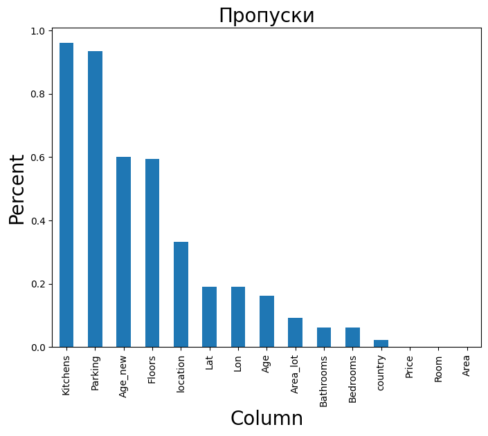

```python
total = df.isnull().sum().sort_values(ascending=False)
percent = (df.isnull().sum() / df.isnull().count()).sort_values(ascending=False)
missing_data = pd.concat([total, percent], axis=1, keys=['Total', 'Percent'])

percent.plot(kind="bar", figsize = (8,6), fontsize = 10)
plt.xlabel("Column", fontsize = 20)
plt.ylabel("Percent", fontsize = 20)
plt.title("Пропуски", fontsize = 20)
```

В Parking и Kitchens очень много пропусков. Просто удалим эти столбцы.

```python
df.drop(columns=['Parking'],inplace=True)
df.drop(columns=['Kitchens'],inplace=True)
```

Строки в Price с пропусками сразу удаляем, так как это таргет, и если они попадут в тренировочную выборку, то мы получим ошибку.

```python
df.drop(index=df[df['Price'].isna() == True].index, inplace=True)
```

Со строками с пропусками Area_lot (площадь земельного участка) будем работать следующим образом: заполним их значением Area (площадь жилого помещения).

```python
df['Area'] = df['Area'].astype(float)
```

```python
df['Area_lot'] = df['Area_lot'].fillna(df['Area'])
```

Пропуски в столбце Floors заполним 1, так как при большем количестве этажей это было бы указано, или же мы такие ситуации обработали в предыдущем пункте. Аналогично поступаем с пропусками в Bedrooms и Bathrooms.

```python
df['Floors'] = df['Floors'].fillna(1)
df['Bedrooms'] = df['Bedrooms'].fillna(1)
df['Bathrooms'] = df['Bathrooms'].fillna(1)
```

Room с пропусками заполним суммой комнат (ванны, спальни).

```python
df['Room'] = df['Room'].fillna(df['Bathrooms'].astype(float) + df['Bedrooms'].astype(float))
```

Пропуски в сountry и location заполним константной строкой (можно пустной, но мы используем 'another' (это не сыграет роли, так как будет использоваться, как категориальный признак)), так как узнать эти данные не получится.

```python
df['country'] = df['country'].fillna('another')
df['location'] = df['location'].fillna('another')
```

Age заполним средним столбца, чтобы данные пропуски не сильно влияли на результат, но при этом учитывались, а Age_new заполним 0, так как это значит, что дом не был на ремонте, как во многих данных.

```python
df['Age'] = df['Age'].fillna(df['Age'].mean())
df['Age_new'] = df['Age_new'].fillna(0)
```

Для получения координат будем использовать данные location и country, которые у нас есть и функцию geocode из модуля geopandas.

```python
df['full_address'] = df.location + ',' + df.country
df.loc[(df['location'] == 'another'), 'full_address'] = df['country']
df.loc[(df['country'] == 'another'), 'full_address'] = df['location']
df.loc[((df['location'] == 'another') & (df['country'] == 'another')), 'full_address'] = ''
```

```python
for place in df[df['Lon'].isna() == True]['full_address'].unique():
    place_short = place
    if len(place) > 70:
        place_short = place.split(',')[-1]
    coord = geocode(place_short, timeout=10)
    if not coord.address.isna()[0]:
        df.loc[((df['Lat'].isna() == True) & (df['full_address'] == place) & (df['Lat'].isna() == True)), 'Lat'] = coord.geometry.iloc[0].x
        df.loc[((df['Lon'].isna() == True) & (df['full_address'] == place) & (df['Lon'].isna() == True)), 'Lon'] = coord.geometry.iloc[0].y
    else:
        df.loc[((df['Lat'].isna() == True) & (df['full_address'] == place) & (df['Lat'].isna() == True)), 'Lat'] = 0
        df.loc[((df['Lon'].isna() == True) & (df['full_address'] == place) & (df['Lon'].isna() == True)), 'Lon'] = 0
```

```python
df.isna().sum()
```

```
Price           0
Bedrooms        0
Bathrooms       0
Area            0
Area_lot        0
Floors          0
Age             0
Age_new         0
Lat             0
Lon             0
Room            0
country         0
location        0
full_address    0
dtype: int64
```

```python
df
```

|  | Price | Bedrooms | Bathrooms | Area | Area_lot | Floors | Age | Age_new | Lat | Lon | Room | country | location | full_address |
| --- | --- | --- | --- | --- | --- | --- | --- | --- | --- | --- | --- | --- | --- | --- |
| 0 | 221900.0 | 3.0 | 1.00 | 109.6220 | 524.8850 | 1.0 | 1955.000000 | 0.0 | 47.511200 | -122.257000 | 4.00 | USA | another | USA |
| 1 | 538000.0 | 3.0 | 2.25 | 238.7530 | 672.7818 | 2.0 | 1951.000000 | 1991.0 | 47.721000 | -122.319000 | 5.25 | USA | another | USA |
| 2 | 180000.0 | 2.0 | 1.00 | 71.5330 | 929.0000 | 1.0 | 1933.000000 | 0.0 | 47.737900 | -122.233000 | 3.00 | USA | another | USA |
| 3 | 604000.0 | 4.0 | 3.00 | 182.0840 | 464.5000 | 1.0 | 1965.000000 | 0.0 | 47.520800 | -122.393000 | 7.00 | USA | another | USA |
| 4 | 510000.0 | 3.0 | 2.00 | 156.0720 | 750.6320 | 1.0 | 1987.000000 | 0.0 | 47.616800 | -122.045000 | 5.00 | USA | another | USA |
| ... | ... | ... | ... | ... | ... | ... | ... | ... | ... | ... | ... | ... | ... | ... |
| 69397 | 3800000.0 | 5.0 | 4.50 | 518.3820 | 518.3820 | 1.0 | 1980.799636 | 0.0 | -122.346134 | 47.616307 | 9.50 | USA | Seattle | Seattle,USA |
| 69398 | 575000.0 | 3.0 | 2.50 | 129.1310 | 129.1310 | 1.0 | 1980.799636 | 0.0 | -122.346134 | 47.616307 | 5.50 | USA | Seattle | Seattle,USA |
| 69399 | 3105000.0 | 3.0 | 2.50 | 274.0550 | 274.0550 | 1.0 | 1980.799636 | 0.0 | -122.346134 | 47.616307 | 5.50 | USA | Seattle | Seattle,USA |
| 69400 | 1807000.0 | 5.0 | 5.00 | 279.6290 | 279.6290 | 1.0 | 1980.799636 | 0.0 | -122.346134 | 47.616307 | 10.00 | USA | Seattle | Seattle,USA |
| 69401 | 895000.0 | 3.0 | 2.00 | 120.8629 | 120.8629 | 1.0 | 1980.799636 | 0.0 | -122.346134 | 47.616307 | 5.00 | USA | Seattle | Seattle,USA |

69398 rows × 14 columns

Больше пропусков нет.

# Визуализация

```python
plt.style.use('Solarize_Light2')
sns.set(rc={'figure.figsize':(12,8)})
plt.figure(figsize=(12,8))
```

Посмотрим на корреляцию признаков с колонкой Price.

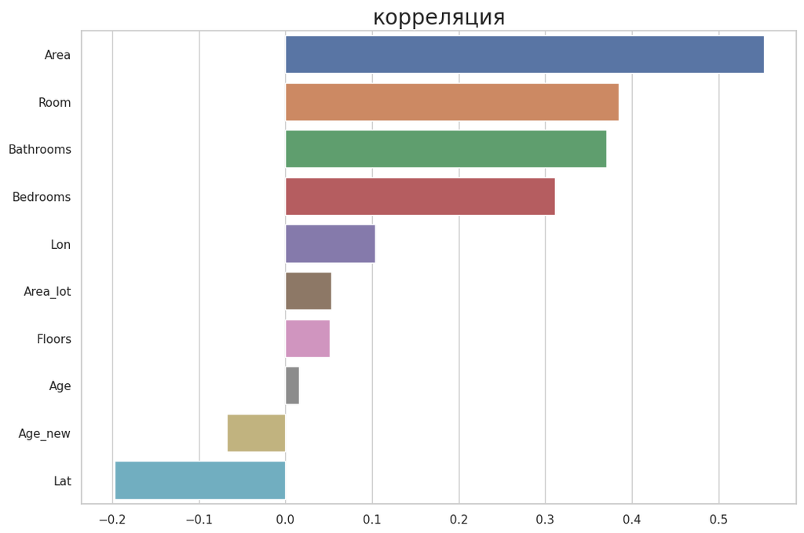

```python
feats = df.drop(columns=['Price']).columns

correlations = df[feats].corrwith(df['Price']).sort_values(ascending=False)

sns.set_style('whitegrid')
sns.barplot(y=correlations.index, x=correlations)
plt.title('корреляция',fontsize=20)
plt.show()
```

Также можно глянуть на тепловую карту.

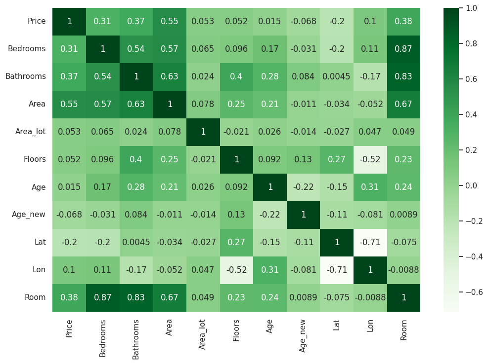

```python
sns.heatmap(df.corr(), annot = True, cmap='Greens')
plt.show()
```

Глянем ещё на распределение объявлений по странам.

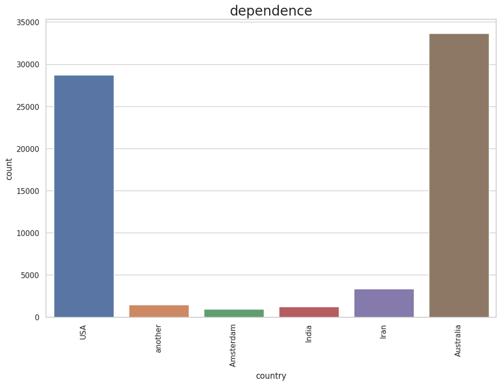

```python
sns.set_style('whitegrid')
sns.countplot(x = df['country'])

plt.xlabel('country')
plt.ylabel('count')
plt.xticks(rotation = 90)
plt.title('dependence', fontsize=20)
plt.show()
```

Можно заметить, что большинство объявлений у нас из Австралии и США. Но это нам не должно никак помешать.

Также посмотрим на то, как распределены средние значения цен по странам.

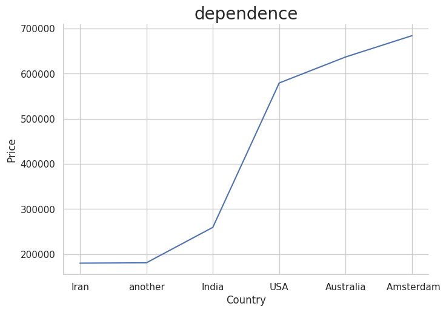

```python
x = df.groupby('country')['Price'].mean().sort_values().index
y = df.groupby('country')['Price'].mean().sort_values()

sns.set_style('whitegrid')
sns.relplot(x = x, y = y, aspect=1.5, kind='line')

plt.xlabel('Country')
plt.ylabel('Price')
plt.title('dependence', fontsize=20)
plt.show()
```

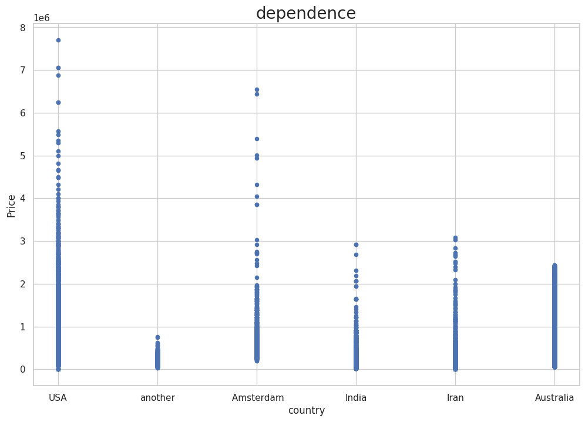

```python
sns.set_style('whitegrid')
plt.scatter('country', 'Price', data=df[df['Price'] < 10000000], s = 20)

plt.xlabel('country')
plt.ylabel('Price')
plt.title('dependence', fontsize=20)
plt.show()
```

Тут же видно, что в датасете, где не была указана страна расположения дома, цены самые низкие, а в Австралии, Амстердаме и США самые высокие (причем в датасете Австралии почти нет выбросов, а в США и Амстердаме достаточно много).

Посмотрим на распределение цены во всем дататсете и для каждой страны отдельно.

По всему датасету:

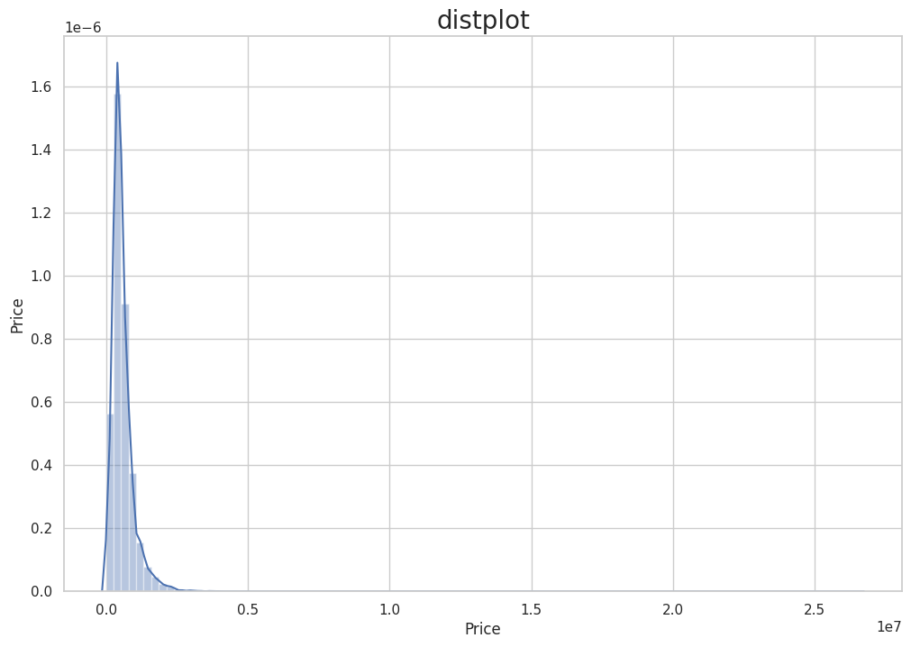

```python
sns.set_style('whitegrid')
sns.distplot(df['Price'],bins=100)

plt.ylabel('Price')
plt.title('distplot', fontsize=20)
plt.show()
```

По каждой стране отдельно (уберем выбросы, чтобы удобно можно было рассмотреть):

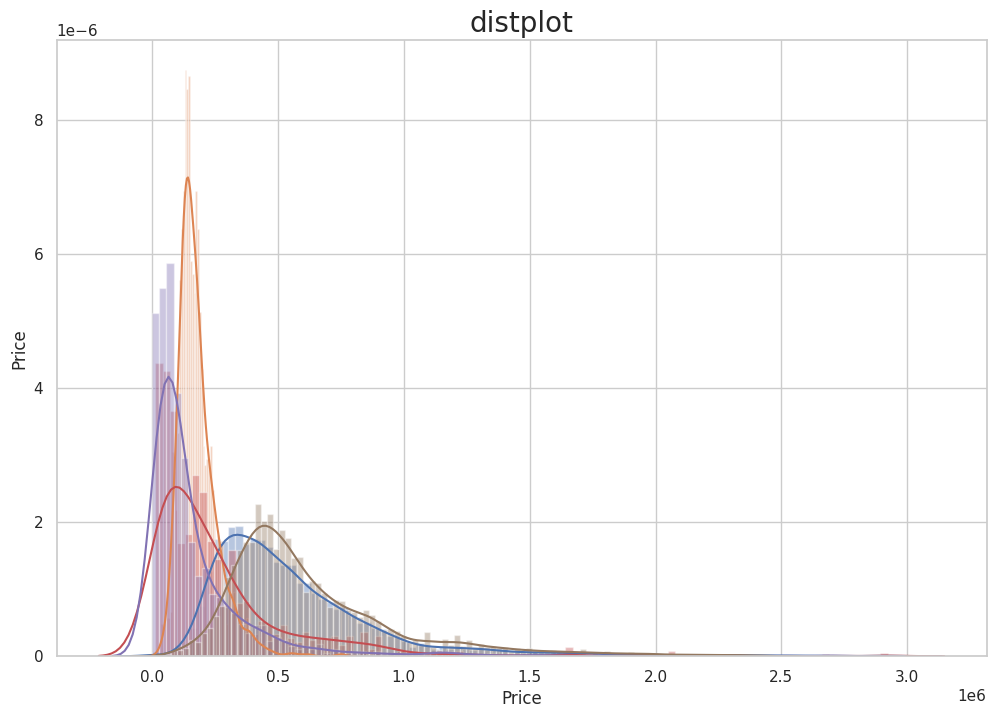

```python
sns.set_style('whitegrid')
sns.distplot(df[df['country'] == 'USA'][df['Price'] < 3000000]['Price'],bins=100)
sns.distplot(df[df['country'] == 'another'][df['Price'] < 3000000]['Price'],bins=100)
sns.distplot(df[df['country'] == 'Amsterdam'][df['Price'] < 3000000]['Price'],bins=100)
sns.distplot(df[df['country'] == 'India'][df['Price'] < 3000000]['Price'],bins=100)
sns.distplot(df[df['country'] == 'Iran'][df['Price'] < 3000000]['Price'],bins=100)
sns.distplot(df[df['country'] == 'Australia'][df['Price'] < 3000000]['Price'],bins=100)


plt.ylabel('Price')
plt.title('distplot', fontsize=20)
plt.show()
```

Посмотрим на зависимость среднего значения цены от количества комнат.

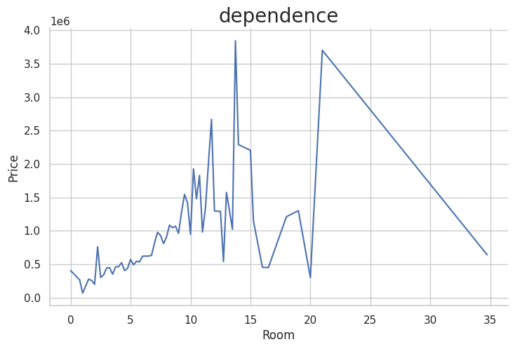

```python
x = df.groupby('Room')['Price'].mean().sort_values().index
y = df.groupby('Room')['Price'].mean().sort_values()

sns.set_style('whitegrid')
sns.relplot(x = x, y = y, aspect=1.5, kind='line')

plt.xlabel('Room')
plt.ylabel('Price')
plt.title('dependence', fontsize=20)
plt.show()
```

Поставим ограничение на количество комнат для удобного рассмотрения графика (до 10 комнат).

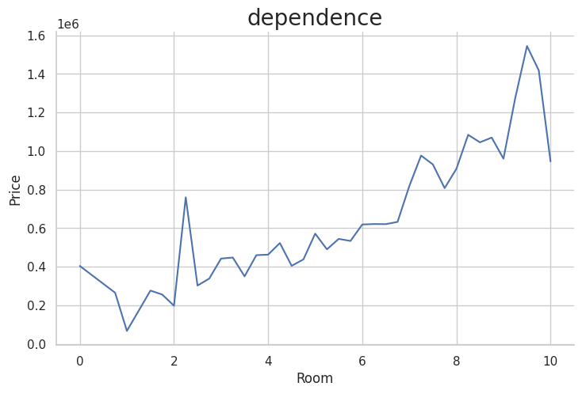

```python
x = df[df['Room'] <= 10].groupby('Room')['Price'].mean().sort_values().index
y = df[df['Room'] <= 10].groupby('Room')['Price'].mean().sort_values()

sns.set_style('whitegrid')
sns.relplot(x = x, y = y, aspect=1.5, kind='line')

plt.xlabel('Room')
plt.ylabel('Price')
plt.title('dependence', fontsize=20)
plt.show()
```

Также можем увидеть, что в датасете, где количество комнат не больше 10, вырисовывается следующая зависимость: чем больше комнат, тем дороже дом. Вполне реальная завиисмость.

Также посмотрим на распределение цены относительно площади жилого помещения.

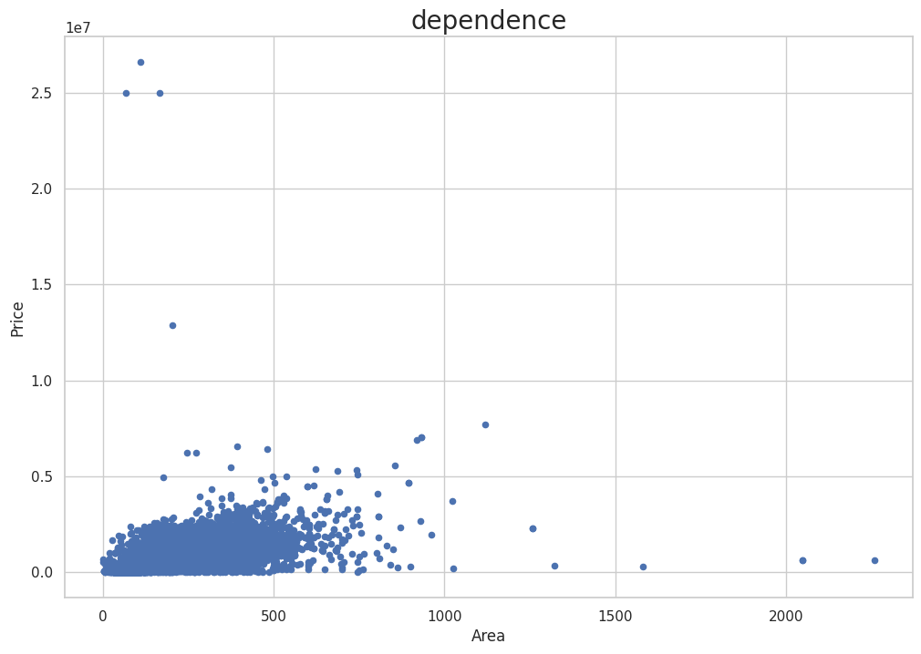

```python
sns.set_style('whitegrid')
plt.scatter('Area', 'Price', data=df, s = 20)

plt.xlabel('Area')
plt.ylabel('Price')
plt.title('dependence', fontsize=20)
plt.show()
```

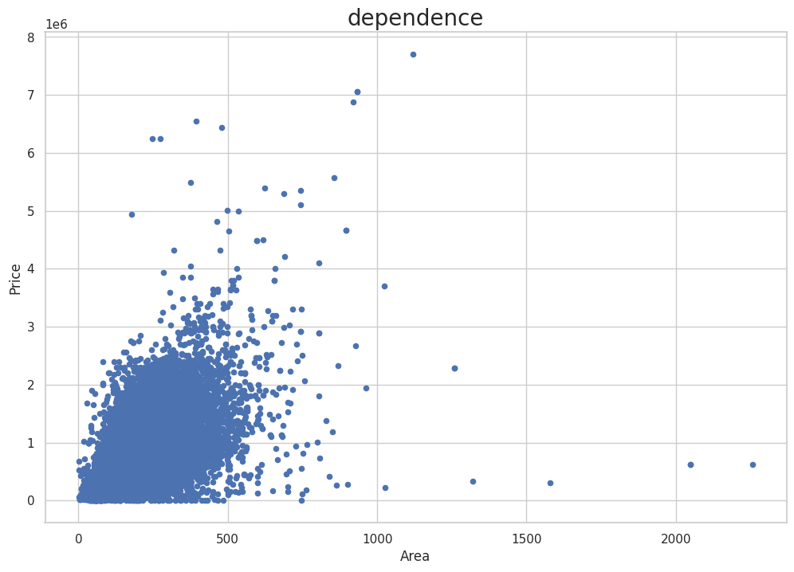

```python
sns.set_style('whitegrid')
plt.scatter('Area', 'Price', data=df[df['Price'] < 10000000], s = 20)

plt.xlabel('Area')
plt.ylabel('Price')
plt.title('dependence', fontsize=20)
plt.show()
```

Также посмотрим на распределение цены относительно количества комнат.

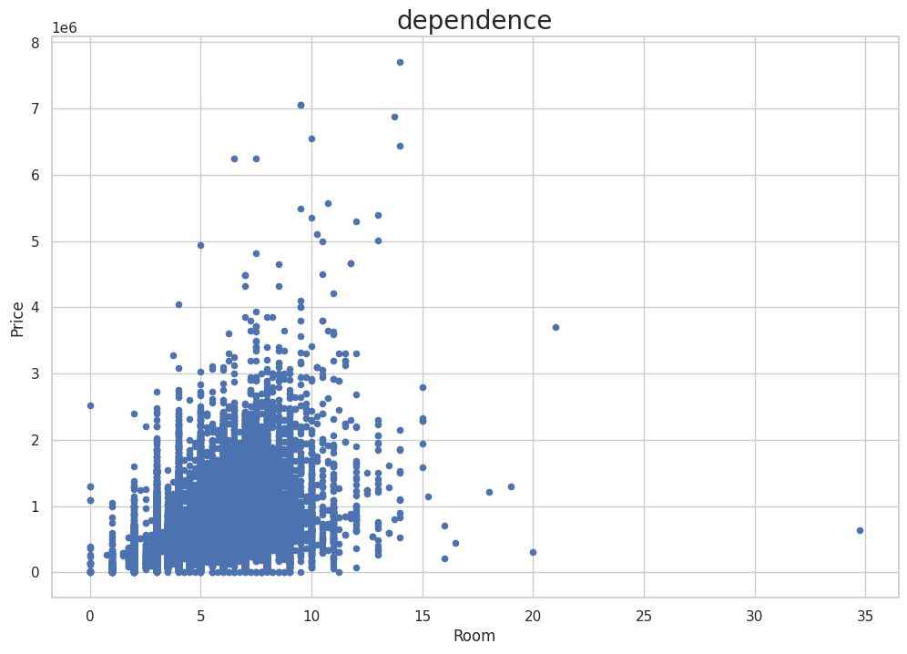

```python
sns.set_style('whitegrid')
plt.scatter('Room', 'Price', data=df[df['Price'] < 10000000], s = 20)

plt.xlabel('Room')
plt.ylabel('Price')
plt.title('dependence', fontsize=20)
plt.show()
```

Аналогично здесь видим зависимость между площадью и ценой и между ценой и количеством комнат, как и раньше.

Также посмотрим на распределение цены относительно количества этажей.

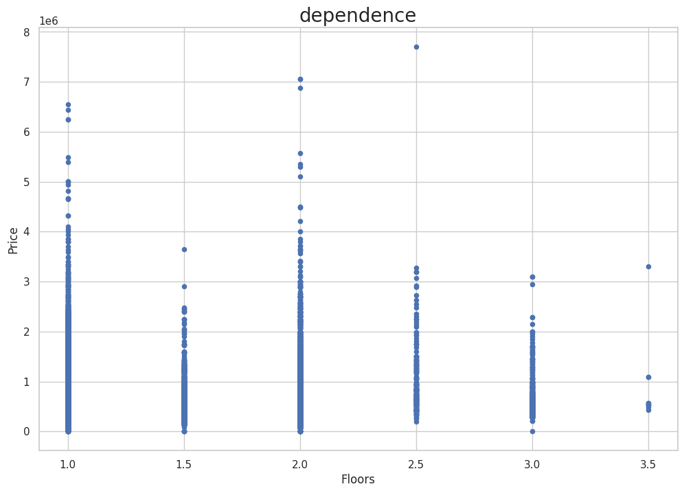

```python
sns.set_style('whitegrid')
plt.scatter('Floors', 'Price', data=df[df['Price'] < 10000000], s = 20)

plt.xlabel('Floors')
plt.ylabel('Price')
plt.title('dependence', fontsize=20)
plt.show()
```

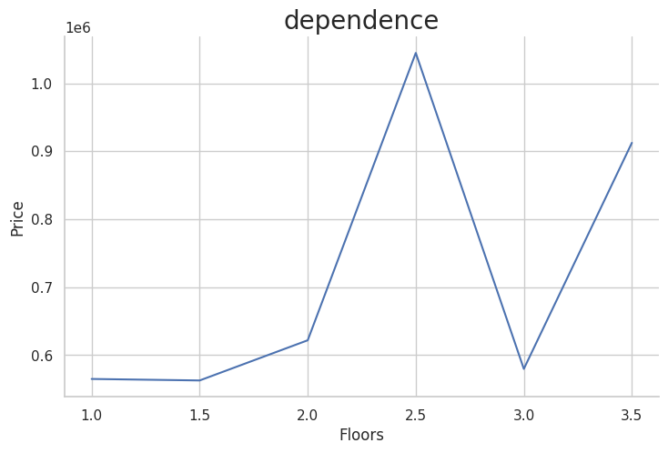

```python
x = df.groupby('Floors')['Price'].mean().sort_values().index
y = df.groupby('Floors')['Price'].mean().sort_values()

sns.set_style('whitegrid')
sns.relplot(x = x, y = y, aspect=1.5, kind='line')

plt.xlabel('Floors')
plt.ylabel('Price')
plt.title('dependence', fontsize=20)
plt.show()
```

Теперь построим на одном графике кривые зависимостей для каждой между количеством комнат и ценой.

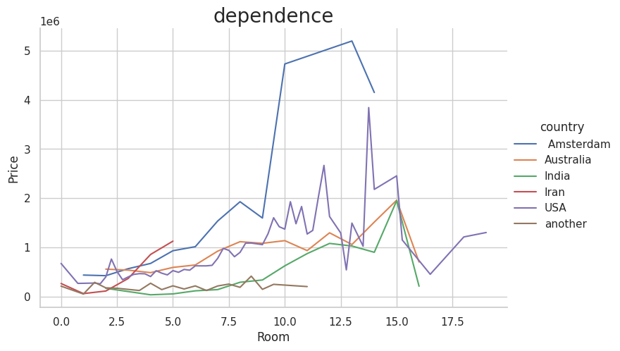

```python
sns.set_style('whitegrid')
sns.relplot(hue = 'country', x = 'Room', y = 'Price', data = df[df['Room'] < 20].groupby(['country', 'Room']).mean(), kind = 'line', aspect=1.5)

plt.xlabel('Room')
plt.ylabel('Price')
plt.title('dependence', fontsize=20)
plt.show()
```

По каждой из стран можно выявить зависимость до 10 комнат (так как случаев, где количество комнат больше 10, совсем мало - выбросы, а значит зависимость ломается). Где-то данная зависимость хорошо заметна, где-то хуже, однако везде она присутствует.

Теперь построим на одном графике кривые зависимостей для каждой между площадью и ценой.

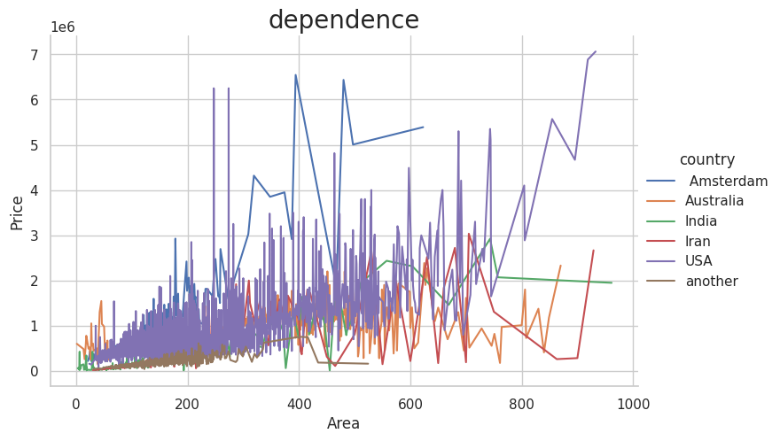

```python
sns.set_style('whitegrid')
sns.relplot(hue = 'country', x = 'Area', y = 'Price', data = df[df['Area'] < 1000].groupby(['country', 'Area']).mean(), kind = 'line', aspect=1.5)

plt.xlabel('Area')
plt.ylabel('Price')
plt.title('dependence', fontsize=20)
plt.show()
```

Здесь графики сильно скачут, но если проследить траекторию, то можно заметить основное - увеличивается площадь <-> увеличивается цена.

# Создание новых признаков

```python
df
```

|  | Price | Bedrooms | Bathrooms | Area | Area_lot | Floors | Age | Age_new | Lat | Lon | Room | country | location | full_address |
| --- | --- | --- | --- | --- | --- | --- | --- | --- | --- | --- | --- | --- | --- | --- |
| 0 | 221900.0 | 3.0 | 1.00 | 109.6220 | 524.8850 | 1.0 | 1955.000000 | 0.0 | 47.511200 | -122.257000 | 4.00 | USA | another | USA |
| 1 | 538000.0 | 3.0 | 2.25 | 238.7530 | 672.7818 | 2.0 | 1951.000000 | 1991.0 | 47.721000 | -122.319000 | 5.25 | USA | another | USA |
| 2 | 180000.0 | 2.0 | 1.00 | 71.5330 | 929.0000 | 1.0 | 1933.000000 | 0.0 | 47.737900 | -122.233000 | 3.00 | USA | another | USA |
| 3 | 604000.0 | 4.0 | 3.00 | 182.0840 | 464.5000 | 1.0 | 1965.000000 | 0.0 | 47.520800 | -122.393000 | 7.00 | USA | another | USA |
| 4 | 510000.0 | 3.0 | 2.00 | 156.0720 | 750.6320 | 1.0 | 1987.000000 | 0.0 | 47.616800 | -122.045000 | 5.00 | USA | another | USA |
| ... | ... | ... | ... | ... | ... | ... | ... | ... | ... | ... | ... | ... | ... | ... |
| 69397 | 3800000.0 | 5.0 | 4.50 | 518.3820 | 518.3820 | 1.0 | 1980.799636 | 0.0 | -122.346134 | 47.616307 | 9.50 | USA | Seattle | Seattle,USA |
| 69398 | 575000.0 | 3.0 | 2.50 | 129.1310 | 129.1310 | 1.0 | 1980.799636 | 0.0 | -122.346134 | 47.616307 | 5.50 | USA | Seattle | Seattle,USA |
| 69399 | 3105000.0 | 3.0 | 2.50 | 274.0550 | 274.0550 | 1.0 | 1980.799636 | 0.0 | -122.346134 | 47.616307 | 5.50 | USA | Seattle | Seattle,USA |
| 69400 | 1807000.0 | 5.0 | 5.00 | 279.6290 | 279.6290 | 1.0 | 1980.799636 | 0.0 | -122.346134 | 47.616307 | 10.00 | USA | Seattle | Seattle,USA |
| 69401 | 895000.0 | 3.0 | 2.00 | 120.8629 | 120.8629 | 1.0 | 1980.799636 | 0.0 | -122.346134 | 47.616307 | 5.00 | USA | Seattle | Seattle,USA |

69398 rows × 14 columns

Создадим признак, который будет отвечать за то, сколько процентнов относительно всей площади жилого помещения составляют спальни и ванные.

Также создадим признаки, которые отвечают соответственно за суммарную площадь отведенную под спальни и под ванные.

```python
df['PercentBeds'] = 0
df.loc[df['Room'] > 0, 'PercentBeds'] = (df['Bedrooms'] * 100 / df['Room'])
df['PercentBaths'] = 0
df.loc[df['Room'] > 0, 'PercentBaths'] = (df['Bathrooms'] * 100 / df['Room'])

df['AreaBeds'] = 0
df.loc[df['Room'] > 0, 'AreaBeds'] = (df['Area']  * df['Bedrooms'] / df['Room'])
df['AreaBaths'] = 0
df.loc[df['Room'] > 0, 'AreaBaths'] = (df['Area'] * df['Bathrooms'] / df['Room'])
```

И создадим более сложные признаки для улучшения работы, например, линейной регрессии, признаки, которые будут равны квадрату, кубу и корню признаком количества спален, ванн, комнат и площадей.

```python
df["Bedrooms2"] = df["Bedrooms"] ** 2
df["Bedrooms3"] = df["Bedrooms"] ** 3
df["BedroomsSq"] = np.sqrt(df["Bedrooms"])

df["Bathrooms2"] = df["Bathrooms"] ** 2
df["Bathrooms3"] = df["Bathrooms"] ** 3
df["BathroomsSq"] = np.sqrt(df["Bathrooms"])

df["Room2"] = df["Room"] ** 2
df["Room3"] = df["Room"] ** 3
df["RoomSq"] = np.sqrt(df["Room"])

df["Area2"] = df["Area"] ** 2
df["Area3"] = df["Area"] ** 3
df["AreaSq"] = np.sqrt(df["Area"])

df["Area_lot2"] = df["Area_lot"] ** 2
df["Area_lot3"] = df["Area_lot"] ** 3
df["Area_lotSq"] = np.sqrt(df["Area_lot"])
```

```python
df
```

|  | Price | Bedrooms | Bathrooms | Area | Area_lot | Floors | Age | Age_new | Lat | Lon | ... | BathroomsSq | Room2 | Room3 | RoomSq | Area2 | Area3 | AreaSq | Area_lot2 | Area_lot3 | Area_lotSq |
| --- | --- | --- | --- | --- | --- | --- | --- | --- | --- | --- | --- | --- | --- | --- | --- | --- | --- | --- | --- | --- | --- |
| 0 | 221900.0 | 3.0 | 1.00 | 109.6220 | 524.8850 | 1.0 | 1955.000000 | 0.0 | 47.511200 | -122.257000 | ... | 1.000000 | 16.0000 | 64.000000 | 2.000000 | 12016.982884 | 1.317326e+06 | 10.470053 | 275504.263225 | 1.446081e+08 | 22.910369 |
| 1 | 538000.0 | 3.0 | 2.25 | 238.7530 | 672.7818 | 2.0 | 1951.000000 | 1991.0 | 47.721000 | -122.319000 | ... | 1.500000 | 27.5625 | 144.703125 | 2.291288 | 57002.995009 | 1.360964e+07 | 15.451634 | 452635.350411 | 3.045248e+08 | 25.938038 |
| 2 | 180000.0 | 2.0 | 1.00 | 71.5330 | 929.0000 | 1.0 | 1933.000000 | 0.0 | 47.737900 | -122.233000 | ... | 1.000000 | 9.0000 | 27.000000 | 1.732051 | 5116.970089 | 3.660322e+05 | 8.457718 | 863041.000000 | 8.017651e+08 | 30.479501 |
| 3 | 604000.0 | 4.0 | 3.00 | 182.0840 | 464.5000 | 1.0 | 1965.000000 | 0.0 | 47.520800 | -122.393000 | ... | 1.732051 | 49.0000 | 343.000000 | 2.645751 | 33154.583056 | 6.036919e+06 | 13.493850 | 215760.250000 | 1.002206e+08 | 21.552262 |
| 4 | 510000.0 | 3.0 | 2.00 | 156.0720 | 750.6320 | 1.0 | 1987.000000 | 0.0 | 47.616800 | -122.045000 | ... | 1.414214 | 25.0000 | 125.000000 | 2.236068 | 24358.469184 | 3.801675e+06 | 12.492878 | 563448.399424 | 4.229424e+08 | 27.397664 |
| ... | ... | ... | ... | ... | ... | ... | ... | ... | ... | ... | ... | ... | ... | ... | ... | ... | ... | ... | ... | ... | ... |
| 69397 | 3800000.0 | 5.0 | 4.50 | 518.3820 | 518.3820 | 1.0 | 1980.799636 | 0.0 | -122.346134 | 47.616307 | ... | 2.121320 | 90.2500 | 857.375000 | 3.082207 | 268719.897924 | 1.392996e+08 | 22.768004 | 268719.897924 | 1.392996e+08 | 22.768004 |
| 69398 | 575000.0 | 3.0 | 2.50 | 129.1310 | 129.1310 | 1.0 | 1980.799636 | 0.0 | -122.346134 | 47.616307 | ... | 1.581139 | 30.2500 | 166.375000 | 2.345208 | 16674.815161 | 2.153236e+06 | 11.363582 | 16674.815161 | 2.153236e+06 | 11.363582 |
| 69399 | 3105000.0 | 3.0 | 2.50 | 274.0550 | 274.0550 | 1.0 | 1980.799636 | 0.0 | -122.346134 | 47.616307 | ... | 1.581139 | 30.2500 | 166.375000 | 2.345208 | 75106.143025 | 2.058321e+07 | 16.554607 | 75106.143025 | 2.058321e+07 | 16.554607 |
| 69400 | 1807000.0 | 5.0 | 5.00 | 279.6290 | 279.6290 | 1.0 | 1980.799636 | 0.0 | -122.346134 | 47.616307 | ... | 2.236068 | 100.0000 | 1000.000000 | 3.162278 | 78192.377641 | 2.186486e+07 | 16.722111 | 78192.377641 | 2.186486e+07 | 16.722111 |
| 69401 | 895000.0 | 3.0 | 2.00 | 120.8629 | 120.8629 | 1.0 | 1980.799636 | 0.0 | -122.346134 | 47.616307 | ... | 1.414214 | 25.0000 | 125.000000 | 2.236068 | 14607.840596 | 1.765546e+06 | 10.993766 | 14607.840596 | 1.765546e+06 | 10.993766 |

69398 rows × 33 columns

# Гипотезы

## Первая гипотеза

Из графика распределения средних цен по странам мы могли заметить, что средняя цена на дом в США находится примерно на середине графика. То есть мы можем выдвинуть следующую нулевую гипотезу:

средняя цена на дом в США равна усредненной цене на дома по остальным странам (по оставшейся части датасета).

Таким образом мы выдвигаем гипотезы:

$H_0: mean(Price_{USA}) = mean(Price_{another-country})$

$H_1: mean(Price_{USA}) != mean(Price_{another-country})$

Данные независимы, и мы можем использовать t-тест или же z-тест со значением value=0.

```python
price_usa = df[df['country'] == 'USA']['Price']
price_another = df[df['country'] != 'USA']['Price']
```

Также для проведения теста надо посмотреть на соотношение дисперсий (должно быть меньше, чем 4:1).

```python
print(np.var(price_usa) / np.var(price_another))
```

```
1.6012743370710898
```

```python
print(np.var(price_another) / np.var(price_usa))
```

```
0.624502608234584
```

Все подходит. Можем проверять.

```python
sts.ttest_ind(price_usa, price_another)
```

```
Ttest_indResult(statistic=2.183727498367649, pvalue=0.028985614639535966)
```

```python
wsts.ztest(price_usa, price_another)
```

```
(2.183727498367649, 0.028982277893672526)
```

Поскольку мы не меняли параметр equal_var при проведении t-теста, он по умолчанию равен True, что говорит о том, что проверялась нулевая гипотеза.

Также при проведении z-теста мы оставили значение 0 (по умолчанию), из-за чего проверялась нулевая гипотеза.

Итог: при проведении двух тестов мы получили pvalue = 0.03 (по умолчанию берем уровень значимости $\alpha$ = 0.05), что меньше $\alpha$, а значит мы отвергаем нулевую гипотезу $\Rightarrow$ $mean(Price_{USA}) != mean(Price_{another})$.

## Вторая гипотеза

Также из того же графика можно заметить, что средняя цена на дома в Иране и в датасете без указания страны были примерно равны.

Проверим тогда такие гипотезы:

$H_0: mean(Price_{Iran}) = mean(Price_{another})$

$H_1: mean(Price_{Iran}) != mean(Price_{another})$

```python
price_iran = df[df['country'] == 'Iran']['Price']
price_another = df[df['country'] == 'another']['Price']
```

```python
wsts.ztest(price_iran, price_another)
```

```
(-0.10913004334343458, 0.9130993460477428)
```

Итог: мы не можем отвергнуть нулевую гипотезу, так как значение вероятности больше $\alpha$.

## Третья гипотеза

Можно попробовать выполнить анализ Уэлча, чтобы посмотреть на равенство по двум столбцам.

Например, выдвинем следующие гипотезы:

$H_0:$ для каждого значения $Floors$ равны $Price$

$H_1:$ для каждого значения $Floors$ не равны $Price$

Для начала надо провести тест Бартлетта для проверки равенства дисперсий между группами.

```python
all = [np.array(df[df['Floors'] == count_floors]['Price']) for count_floors in df['Floors'].unique()]
```

```python
sts.bartlett(all[0], all[1], all[2], all[3], all[4], all[5])
```

```
BartlettResult(statistic=754.1499456906078, pvalue=9.575288380145696e-161)
```

Соответственно получаем pvalue близкое к 0, что отвергает гипотезу о равенстве дисперсий, и мы можем переходить к анализу Уэлча.

```python
pg.welch_anova(dv='Price', between='Floors', data=df)
```

|  | Source | ddof1 | ddof2 | F | p-unc | np2 |
| --- | --- | --- | --- | --- | --- | --- |
| 0 | Floors | 5 | 99.020649 | 44.406481 | 8.086012e-24 | 0.005892 |

Получаем pvalue (почти 0) меньшее $\alpha$ $\Rightarrow$ гипотеза о равенстве цен отклоняется.

Также можно посмотреть на равенство между каждой группой:

```python
z = pg.pairwise_gameshowell(dv='Price', between='Floors', data=df)
z['pval'] = z['pval'].round(10)
z
```

|  | A | B | mean(A) | mean(B) | diff | se | T | df | pval | hedges |
| --- | --- | --- | --- | --- | --- | --- | --- | --- | --- | --- |
| 0 | 1.0 | 1.5 | 5.649069e+05 | 5.626986e+05 | 2208.317411 | 6585.474543 | 0.335332 | 2759.640863 | 0.999441 | 0.005194 |
| 1 | 1.0 | 2.0 | 5.649069e+05 | 6.218367e+05 | -56929.724866 | 4585.067025 | -12.416334 | 14976.425111 | 0.000000 | -0.132299 |
| 2 | 1.0 | 2.5 | 5.649069e+05 | 1.044823e+06 | -479915.743968 | 56714.159605 | -8.462009 | 201.416629 | 0.000000 | -1.112469 |
| 3 | 1.0 | 3.0 | 5.649069e+05 | 5.796986e+05 | -14791.609603 | 12804.805975 | -1.155161 | 770.979135 | 0.857818 | -0.034524 |
| 4 | 1.0 | 3.5 | 5.649069e+05 | 9.125000e+05 | -347593.050898 | 276138.120714 | -1.258765 | 9.000786 | 0.799111 | -0.809193 |
| 5 | 1.5 | 2.0 | 5.626986e+05 | 6.218367e+05 | -59138.042277 | 7598.326012 | -7.783036 | 4690.416751 | 0.000000 | -0.142619 |
| 6 | 1.5 | 2.5 | 5.626986e+05 | 1.044823e+06 | -482124.061379 | 57036.896990 | -8.452845 | 206.037903 | 0.000000 | -1.297841 |
| 7 | 1.5 | 3.0 | 5.626986e+05 | 5.796986e+05 | -16999.927014 | 14165.972421 | -1.200054 | 1132.751028 | 0.836940 | -0.053697 |
| 8 | 1.5 | 3.5 | 5.626986e+05 | 9.125000e+05 | -349801.368309 | 276204.586186 | -1.266457 | 9.009455 | 0.795376 | -1.123944 |
| 9 | 2.0 | 2.5 | 6.218367e+05 | 1.044823e+06 | -422986.019101 | 56840.671908 | -7.441608 | 203.219737 | 0.000000 | -0.951664 |
| 10 | 2.0 | 3.0 | 6.218367e+05 | 5.796986e+05 | 42138.115264 | 13353.993384 | 3.155469 | 911.240116 | 0.020487 | 0.098097 |
| 11 | 2.0 | 3.5 | 6.218367e+05 | 9.125000e+05 | -290663.326032 | 276164.131985 | -1.052502 | 9.004178 | 0.888184 | -0.667637 |
| 12 | 2.5 | 3.0 | 1.044823e+06 | 5.796986e+05 | 465124.134365 | 58084.440252 | 8.007723 | 221.449055 | 0.000000 | 0.964380 |
| 13 | 2.5 | 3.5 | 1.044823e+06 | 9.125000e+05 | 132322.693069 | 281890.228378 | 0.469412 | 9.773734 | 0.996258 | 0.163048 |
| 14 | 3.0 | 3.5 | 5.796986e+05 | 9.125000e+05 | -332801.441296 | 276422.806605 | -1.203958 | 9.037960 | 0.825019 | -0.933803 |

## Четвертая гипотеза

Попробуем сделать то, что было в первых двух гипотезах, обобщенно аналогично третей гипотезе.

$H_0:$ для каждого значения $country$ равны $Price$

$H_1:$ для каждого значения $country$ не равны $Price$

```python
all = [np.array(df[df['country'] == country]['Price']) for country in df['country'].unique()]
```

```python
sts.bartlett(all[0], all[1], all[2], all[3], all[4], all[5])
```

```
BartlettResult(statistic=7795.557156164448, pvalue=0.0)
```

Переходим к анализу Уэлтча.

```python
pg.welch_anova(dv='Price', between='country', data=df)
```

|  | Source | ddof1 | ddof2 | F | p-unc | np2 |
| --- | --- | --- | --- | --- | --- | --- |
| 0 | country | 5 | 4788.796889 | 6358.947736 | 0.0 | 0.079832 |

В среднем гипотеза о равенсте отвергается.

```python
z = pg.pairwise_gameshowell(dv='Price', between='country', data=df)
z['pval'] = z['pval'].round(10)
z
```

|  | A | B | mean(A) | mean(B) | diff | se | T | df | pval | hedges |
| --- | --- | --- | --- | --- | --- | --- | --- | --- | --- | --- |
| 0 | Amsterdam | Australia | 684271.961522 | 637072.005794 | 47199.955728 | 19643.114683 | 2.402875 | 937.182988 | 0.156189 | 0.129621 |
| 1 | Amsterdam | India | 684271.961522 | 259451.731358 | 424820.230164 | 21430.872919 | 19.822815 | 1289.388778 | 0.000000 | 0.938976 |
| 2 | Amsterdam | Iran | 684271.961522 | 180125.072855 | 504146.888666 | 20108.187886 | 25.071722 | 1028.192063 | 0.000000 | 1.375728 |
| 3 | Amsterdam | USA | 684271.961522 | 579428.974073 | 104842.987449 | 19755.848209 | 5.306934 | 958.871603 | 0.000002 | 0.214313 |
| 4 | Amsterdam | another | 684271.961522 | 180921.195890 | 503350.765631 | 19657.382647 | 25.606195 | 939.835603 | 0.000000 | 1.346178 |
| 5 | Australia | India | 637072.005794 | 259451.731358 | 377620.274436 | 8997.457492 | 41.969665 | 1383.481427 | 0.000000 | 1.065700 |
| 6 | Australia | Iran | 637072.005794 | 180125.072855 | 456946.932938 | 5100.112481 | 89.595462 | 4590.091115 | 0.000000 | 1.308676 |
| 7 | Australia | USA | 637072.005794 | 579428.974073 | 57643.031721 | 3459.113429 | 16.664106 | 51823.598698 | 0.000000 | 0.137064 |
| 8 | Australia | another | 637072.005794 | 180921.195890 | 456150.809904 | 2843.346582 | 160.427439 | 4941.263440 | 0.000000 | 1.308002 |
| 9 | India | Iran | 259451.731358 | 180125.072855 | 79326.658503 | 9972.036249 | 7.954911 | 2024.867121 | 0.000000 | 0.278677 |
| 10 | India | USA | 259451.731358 | 579428.974073 | -319977.242714 | 9240.986167 | -34.625876 | 1538.832164 | 0.000000 | -0.667314 |
| 11 | India | another | 259451.731358 | 180921.195890 | 78530.535468 | 9028.564638 | 8.698009 | 1399.055153 | 0.000000 | 0.356907 |
| 12 | Iran | USA | 180125.072855 | 579428.974073 | -399303.901217 | 5518.399347 | -72.358645 | 6210.541064 | 0.000000 | -0.853527 |
| 13 | Iran | another | 180125.072855 | 180921.195890 | -796.123035 | 5154.792472 | -0.154443 | 4418.798613 | 0.999988 | -0.003419 |
| 14 | USA | another | 579428.974073 | 180921.195890 | 398507.778182 | 3539.237746 | 112.597064 | 10357.313058 | 0.000000 | 0.840791 |

Наша вторая гипотеза подтвердилась, и мы можем проследить, между какими странами равенство нельзя отвергнуть (Амстердам-Австралия, Иран-another).

## Пятая гипотеза

Аналогично проверим следующие гипотезы:

$H_0:$ для каждого значения $Floors$ равны $Room$

$H_1:$ для каждого значения $Floors$ не равны $Room$

```python
all = [np.array(df[df['Floors'] == Floors]['Room']) for Floors in df['Floors'].unique()]
```

```python
sts.bartlett(all[0], all[1], all[2], all[3], all[4], all[5])
```

```
BartlettResult(statistic=906.4148606491302, pvalue=1.0883279767344392e-193)
```

```python
pg.welch_anova(dv='Room', between='Floors', data=df)
```

|  | Source | ddof1 | ddof2 | F | p-unc | np2 |
| --- | --- | --- | --- | --- | --- | --- |
| 0 | Floors | 5 | 99.020277 | 1265.06389 | 5.095414e-88 | 0.067195 |

```python
z = pg.pairwise_gameshowell(dv='Room', between='Floors', data=df)
z['pval'] = z['pval'].round(5)
z
```

|  | A | B | mean(A) | mean(B) | diff | se | T | df | pval | hedges |
| --- | --- | --- | --- | --- | --- | --- | --- | --- | --- | --- |
| 0 | 1.0 | 1.5 | 5.125000 | 5.294393 | -0.169393 | 0.028319 | -5.981681 | 2638.873460 | 0.00000 | -0.108208 |
| 1 | 1.0 | 2.0 | 5.125000 | 6.234625 | -1.109625 | 0.013947 | -79.557650 | 17711.110934 | 0.00000 | -0.725863 |
| 2 | 1.0 | 2.5 | 5.125000 | 6.914604 | -1.789604 | 0.124383 | -14.387884 | 202.167546 | 0.00000 | -1.136113 |
| 3 | 1.0 | 3.0 | 5.125000 | 5.473684 | -0.348684 | 0.048576 | -7.178074 | 768.875417 | 0.00000 | -0.221913 |
| 4 | 1.0 | 3.5 | 5.125000 | 4.975000 | 0.150000 | 1.064896 | 0.140859 | 9.000710 | 0.99999 | 0.095243 |
| 5 | 1.5 | 2.0 | 5.294393 | 6.234625 | -0.940233 | 0.030116 | -31.220016 | 3347.185846 | 0.00000 | -0.735700 |
| 6 | 1.5 | 2.5 | 5.294393 | 6.914604 | -1.620211 | 0.127214 | -12.736063 | 221.170947 | 0.00000 | -1.178992 |
| 7 | 1.5 | 3.0 | 5.294393 | 5.473684 | -0.179292 | 0.055427 | -3.234753 | 1260.851780 | 0.01577 | -0.134868 |
| 8 | 1.5 | 3.5 | 5.294393 | 4.975000 | 0.319393 | 1.065230 | 0.299834 | 9.012024 | 0.99955 | 0.236748 |
| 9 | 2.0 | 2.5 | 6.234625 | 6.914604 | -0.679979 | 0.124804 | -5.448361 | 204.922078 | 0.00000 | -0.532854 |
| 10 | 2.0 | 3.0 | 6.234625 | 5.473684 | 0.760941 | 0.049646 | 15.327384 | 838.622083 | 0.00000 | 0.600097 |
| 11 | 2.0 | 3.5 | 6.234625 | 4.975000 | 1.259625 | 1.064945 | 1.182808 | 9.002378 | 0.83459 | 0.993139 |
| 12 | 2.5 | 3.0 | 6.914604 | 5.473684 | 1.440920 | 0.133196 | 10.818022 | 264.235333 | 0.00000 | 1.014386 |
| 13 | 2.5 | 3.5 | 6.914604 | 4.975000 | 1.939604 | 1.072094 | 1.809174 | 9.246460 | 0.50368 | 1.037728 |
| 14 | 3.0 | 3.5 | 5.473684 | 4.975000 | 0.498684 | 1.065961 | 0.467826 | 9.036783 | 0.99624 | 0.368168 |

Таким образом делаем вывод, что случаи объявлений, где количесво этажей более 2 являются скорее выбросами.

# Машинное обучение

## Подготовка

Разбиваем выборку.

```python
train, test = train_test_split(df, test_size=0.3)
```

Мы хотим предсказывать цену дома по признакам, как описывалось в начале работы.

```python
X_train = train.drop(['Price'], axis=1)
X_test = test.drop(['Price'], axis=1)
y_train = train['Price']
y_test = test['Price']
```

Посмотрим на среднее значение и медиану таргета, чтобы можно было оценить будущую модель.

```python
print(train['Price'].mean())
print(train['Price'].median())
train['Price'].sort_values()
```

```
575773.0310825888
485000.0
```

```
29647           0.0
29644           0.0
29612           0.0
29446           0.0
29623           0.0
            ...
9254      6885000.0
3914      7062500.0
7252      7700000.0
22972    25000000.0
29439    26590000.0
Name: Price, Length: 48578, dtype: float64
```

Для оценки моделей будем использовать две метрики: RMSE (чтобы понимать то, на сколько единиц (в нашем случае долларов) ошибается модель в цене) и R^2 (чтобы понимать, насколько эффективна наша модель).

## Ridge-регрессия

Обучим обычную Ridge-регрессию на признаках, которые были изначально (без искусственно созданных).

Будем использовать One-Hot Encoding для категориальных признаков.

```python
notnum_feats = ['country', 'location', 'full_address']
num_feats = ['Bedrooms', 'Bathrooms', 'Area', 'Area_lot', 'Floors', 'Age',
                'Age_new', 'Lat', 'Lon', 'Room']
```

```python
X_train_now = X_train[notnum_feats + num_feats]
X_test_now = X_test[notnum_feats + num_feats]
```

```python
column_transformer = ColumnTransformer([
    ('ohe', OneHotEncoder(handle_unknown="ignore"), notnum_feats),
])

pipeline = Pipeline(steps=[
    ('ohe_and_scaling', column_transformer),
    ('regression', Ridge())
])

model = pipeline.fit(X_train_now, y_train)
y_pred = model.predict(X_test_now)
y_train_pred = model.predict(X_train_now)

print("Test RMSE = %.4f" % mean_squared_error(y_test, y_pred, squared=False))
print("Train RMSE = %.4f" % mean_squared_error(y_train, y_train_pred, squared=False))

print("Test R^2 = %.4f" % r2_score(y_test, y_pred))
print("Train R^2 = %.4f" % r2_score(y_train, y_train_pred))
```

```
Test RMSE = 351963.1790
Train RMSE = 341506.7768
Test R^2 = 0.3244
Train R^2 = 0.3664
```

Теперь попробуем отнормировать численные признаки, чтобы качество модели улучшилось.

```python
column_transformer = ColumnTransformer([
    ('ohe', OneHotEncoder(handle_unknown="ignore"), notnum_feats),
    ('scaling', StandardScaler(), num_feats)
])

pipeline = Pipeline(steps=[
    ('ohe_and_scaling', column_transformer),
    ('regression', Ridge())
])

model = pipeline.fit(X_train_now, y_train)
y_pred = model.predict(X_test_now)
y_train_pred = model.predict(X_train_now)

print("Test RMSE = %.4f" % mean_squared_error(y_test, y_pred, squared=False))
print("Train RMSE = %.4f" % mean_squared_error(y_train, y_train_pred, squared=False))

print("Test R^2 = %.4f" % r2_score(y_test, y_pred))
print("Train R^2 = %.4f" % r2_score(y_train, y_train_pred))
```

```
Test RMSE = 297401.8903
Train RMSE = 278976.0595
Test R^2 = 0.5176
Train R^2 = 0.5772
```

На тестовой выборке получили меньшую ошибку RMSE, что означает следущее: модель предсказывает цену дома с ошибкой в то количество едениц, чему равна метрика.

Метрика R^2 дала значение чуть больше половины, но все равно мало. Модель считается идеальной по этой метрике, когда значение стремится к 1.

Теперь обучим такую же регрессию, но с новыми признаками.

```python
notnum_feats = ['country', 'location', 'full_address']
num_feats = ['Bedrooms', 'Bathrooms', 'Area', 'Area_lot', 'Floors', 'Age',
                'Age_new', 'Lat', 'Lon', 'Room',
                'PercentBeds', 'PercentBaths', 'AreaBeds', 'AreaBaths', 'Bedrooms2',
                'Bedrooms3', 'BedroomsSq', 'Bathrooms2', 'Bathrooms3', 'BathroomsSq',
                'Room2', 'Room3', 'RoomSq', 'Area2', 'Area3', 'AreaSq', 'Area_lot2',
                'Area_lot3', 'Area_lotSq']
```

```python
column_transformer = ColumnTransformer([
    ('ohe', OneHotEncoder(handle_unknown="ignore"), notnum_feats),
    ('scaling', StandardScaler(), num_feats)
])

pipeline = Pipeline(steps=[
    ('ohe_and_scaling', column_transformer),
    ('regression', Ridge())
])

model = pipeline.fit(X_train, y_train)
y_pred = model.predict(X_test)
y_train_pred = model.predict(X_train)

print("Test RMSE = %.4f" % mean_squared_error(y_test, y_pred, squared=False))
print("Train RMSE = %.4f" % mean_squared_error(y_train, y_train_pred, squared=False))

print("Test R^2 = %.4f" % r2_score(y_test, y_pred))
print("Train R^2 = %.4f" % r2_score(y_train, y_train_pred))
```

```
Test RMSE = 290563.7277
Train RMSE = 273917.5212
Test R^2 = 0.5395
Train R^2 = 0.5924
```

Качество с добавленными признаками улучшилось.

Теперь RMSE даёт ошибку еще меньше. Уже получше. Значит созданные признаки улучшают модель.

R^2 также улучшилось.

## Lasso-регрессия

Теперь попробуем обучить Lasso-регрессию на всех признаках.

```python
column_transformer = ColumnTransformer([
    ('ohe', OneHotEncoder(handle_unknown="ignore"), notnum_feats),
    ('scaling', StandardScaler(), num_feats)
])

pipeline = Pipeline(steps=[
    ('ohe_and_scaling', column_transformer),
    ('regression', Lasso())
])

model = pipeline.fit(X_train, y_train)
y_pred = model.predict(X_test)
y_train_pred = model.predict(X_train)

print("Test RMSE = %.4f" % mean_squared_error(y_test, y_pred, squared=False))
print("Train RMSE = %.4f" % mean_squared_error(y_train, y_train_pred, squared=False))

print("Test R^2 = %.4f" % r2_score(y_test, y_pred))
print("Train R^2 = %.4f" % r2_score(y_train, y_train_pred))
```

```
Test RMSE = 293059.4767
Train RMSE = 273554.5737
Test R^2 = 0.5316
Train R^2 = 0.5935
```

Тут качество получили немного хуже. Значит далее будем работать с Ridge-регрессией.

## Логистическая регрессия

Попробуем теперь ввести классификацию дороговизны дома таким образом, что он будет равен 1 в тех случаях, когда цена дома больше среднего значения таргета, и равен 0 - меньше.

Оценивать будем с помощью PR-AUC и AUC-ROC, чтобы избавиться от проблемы возможной неравности классов.

```python
mean_value = y_train.mean()
```

```python
y_train_log = pd.DataFrame(y_train > mean_value)
y_test_log = pd.DataFrame(y_test > mean_value)

y_train_log.loc[y_train_log['Price'] == True, 'Price'] = 1
y_train_log.loc[y_train_log['Price'] == False, 'Price'] = 0
y_train_log = y_train_log['Price']
y_train_log = y_train_log.astype('int')

y_test_log.loc[y_test_log['Price'] == True, 'Price'] = 1
y_test_log.loc[y_test_log['Price'] == False, 'Price'] = 0
y_test_log = y_test_log['Price']
y_test_log = y_test_log.astype('int')
```

```python
column_transformer = ColumnTransformer([
    ('ohe', OneHotEncoder(handle_unknown="ignore"), notnum_feats),
    ('scaling', StandardScaler(), num_feats)
])

pipeline = Pipeline(steps=[
    ('ohe_and_scaling', column_transformer),
    ('regression', LogisticRegression(max_iter=100000))
])

model = pipeline.fit(X_train, y_train_log)

precision, recall, _ = precision_recall_curve(y_test_log, model.decision_function(X_test))
print('Test PR-AUC: %.5f' %auc(recall, precision))
print('Test AUC-ROC: %.5f' % roc_auc_score(y_test_log, model.decision_function(X_test)))

precision, recall, _ = precision_recall_curve(y_train_log, model.decision_function(X_train))
print('Train PR-AUC: %.5f' %auc(recall, precision))
print('Train AUC-ROC: %.5f' % roc_auc_score(y_train_log, model.decision_function(X_train)))
```

```
Test PR-AUC: 0.88843
Test AUC-ROC: 0.92854
Train PR-AUC: 0.89854
Train AUC-ROC: 0.93454
```

Тут мы получили очень неплохие значения метрик.

AUC-ROC получился около 0.93, что довольно близко к 1. Это хорошо для данной метрики.

Значение PR-AUC мы получили близко 0.9, что также означает хорошее предсказание.

## Random Forest

Попробуем обучить случайный лес.

```python
column_transformer = ColumnTransformer([
    ('ohe', OneHotEncoder(handle_unknown="ignore"), notnum_feats),
    ('scaling', StandardScaler(), num_feats)
])

pipeline = Pipeline(steps=[
    ('ohe_and_scaling', column_transformer),
    ('regression', RandomForestRegressor())
])

model = pipeline.fit(X_train, y_train)
y_pred = model.predict(X_test)
y_train_pred = model.predict(X_train)

print("Test RMSE = %.4f" % mean_squared_error(y_test, y_pred, squared=False))
print("Train RMSE = %.4f" % mean_squared_error(y_train, y_train_pred, squared=False))

print("Test R^2 = %.4f" % r2_score(y_test, y_pred))
print("Train R^2 = %.4f" % r2_score(y_train, y_train_pred))
```

```
Test RMSE = 269268.5008
Train RMSE = 97288.1616
Test R^2 = 0.6046
Train R^2 = 0.9486
```

Результат получился лучше, чем при линейной регрессии.

RMSE на тестовой выборке получился меньший. R^2 - больший.

RMSE на обучающей выборке получился около 100 000. R^2 - около 0.95. Довольно сильное улучшение.

## Гиперпараметры

Попробуем подобрать параметр альфа для линейной регрессии.

```python
column_transformer = ColumnTransformer([
    ('ohe', OneHotEncoder(handle_unknown="ignore"), notnum_feats),
    ('scaling', StandardScaler(), num_feats)
])

pipeline = Pipeline(steps=[
    ('ohe_and_scaling', column_transformer),
    ('regression', Ridge())
])

param_grid = [{'regression__alpha' : np.linspace(0, 0.5, 50)}]

clf = GridSearchCV(pipeline, param_grid = param_grid, cv = 4, scoring = 'r2', n_jobs=-1)

model = clf.fit(X_train, y_train)
y_pred = model.predict(X_test)
y_train_pred = model.predict(X_train)

print("Test RMSE = %.4f" % mean_squared_error(y_test, y_pred, squared=False))
print("Train RMSE = %.4f" % mean_squared_error(y_train, y_train_pred, squared=False))

print("Test R^2 = %.4f" % r2_score(y_test, y_pred))
print("Train R^2 = %.4f" % r2_score(y_train, y_train_pred))
```

```
Test RMSE = 293269.7068
Train RMSE = 273108.2241
Test R^2 = 0.5309
Train R^2 = 0.5948
```

Подбирать параметры для логистической регрессии и случайного леса также можно, но мы уже получили довольно хорошие результаты на данных моделях, и код для подбора их параметров работает очень долго. Код оставим ниже и перейдём к выводам.

```python
X_train_log = X_train[num_feats]
X_test_log = X_test[num_feats]

pipeline = Pipeline(steps=[
    ('ohe_and_scaling', column_transformer),
    ('regression', LogisticRegression(max_iter=100000))
])

param_grid = [{'regression__penalty' : ['l2'],
               'regression__C' : [1, 10, 100, 1000],
               'regression__solver' : ['newton-cg', 'sag', 'lbfgs', 'liblinear', 'saga'],
               'regression__class_weight' : ['balanced', None]}]

clf = GridSearchCV(pipeline, param_grid = param_grid, cv = 4, scoring = 'roc_auc', n_jobs=-1)

model = clf.fit(X_train, y_train_log)

precision, recall, _ = precision_recall_curve(y_test_log, model.decision_function(X_test))
print('Test PR-AUC: %.5f' %auc(recall, precision))
print('Test AUC-ROC: %.5f' % roc_auc_score(y_test_log, model.decision_function(X_test)))

precision, recall, _ = precision_recall_curve(y_train_log, model.decision_function(X_train))
print('Train PR-AUC: %.5f' %auc(recall, precision))
print('Train AUC-ROC: %.5f' % roc_auc_score(y_train_log, model.decision_function(X_train)))
```

```
Test PR-AUC: 0.89330
Test AUC-ROC: 0.93246
Train PR-AUC: 0.90593
Train AUC-ROC: 0.93950
```

Также посмотрим, что мы получим с RandomForest.

```python
pipeline = Pipeline(steps=[
    ('ohe_and_scaling', column_transformer),
    ('regression', RandomForestRegressor())
])

param_grid = [{'regression__min_samples_leaf': [5, 10, 15, 20, 25],
                'regression__max_depth': [6, 9, 12, 15, 20]}]

clf = GridSearchCV(pipeline, param_grid = param_grid, cv = 4, scoring = 'r2', n_jobs=-1)

model = clf.fit(X_train, y_train)
y_pred = model.predict(X_test)
y_train_pred = model.predict(X_train)

print("Test RMSE = %.4f" % mean_squared_error(y_test, y_pred, squared=False))
print("Train RMSE = %.4f" % mean_squared_error(y_train, y_train_pred, squared=False))

print("Test R^2 = %.4f" % r2_score(y_test, y_pred))
print("Train R^2 = %.4f" % r2_score(y_train, y_train_pred))
```

[output not shown]

# Выводы

Нам удалось выделить основные признаки, которые наибольшим образом коррелируют с целевой переменной, а именно с ценой. Также были проверены различные гипотезы и визуализированы закономерности в данных.

С помощью полученного нами датасета можно обучить логистическую регрессию для классификации домов по различным признакам, а также неплохо справляется с задачей предсказания цены дома случайный лес.

Нам удалось выявить новые признаки, которые улучшили метрики моделей, а также при помощи визуализаций и гипотез выделить закономерности в данных и выявить выбросы, которые могут ломать данные зависимости.